# RUN 2 Grad-CAM Localization Investigation

## Purpose

This notebook evaluates whether 3D Grad-CAM localization for the Run 2 3D ResNet-18 PDAC classifier is spatially associated with the annotated PDAC lesion, going beyond the primary Grad-CAM evaluation notebook with three additions:

1. **A corrected patient-specific random null**, using a tie-aware percentile statistic.
2. **A randomized-weight model control** -- a fresh, untrained copy of the same architecture, used to check whether any apparent localization signal could be explained by architecture/geometry alone rather than learned weights.
3. **A paired layer3-vs-layer4 comparison**, using the *same* random coordinate draws for both layers per case, so any difference reflects the layer, not extra randomization noise.

## Design principles carried over from the primary Grad-CAM notebook

- The independent statistical unit is the **patient/case** (N=103 PDAC test cases), never the thousands of random points sampled per case.
- Backpropagation target is the **raw classification logit**, never `sigmoid(logit)`.
- `PDAC_TUMOR_LABEL = 1` and `PANCREAS_LABEL = 4` are separate, documented labels, verified against the actual processed masks before any GPU work.
- No case is silently excluded: ROI-boundary cases, misclassified cases, and low-confidence cases are all retained and flagged, not dropped.
- `strict=True` checkpoint loading -- no silent architecture mismatch is tolerated.
- All PDAC-positive test cases are the primary analysis population; correctly-classified-only is a secondary, explicitly labeled subset.

## What this notebook does not claim

Statistically significant proximity between the Grad-CAM peak and the annotated lesion is evidence of **spatial association**, not proof that the model is "looking at" or "reasoning about" the tumor in a causal sense. The randomized-model control addresses one specific alternative explanation (pure architecture/geometry artifact); it does not, by itself, establish causal explanation faithfulness. Language throughout this notebook is written to reflect that distinction explicitly.

## Cell 2 — Imports and configuration

```python
# ============================================================
# CELL 2 — IMPORTS AND GLOBAL CONFIGURATION
# ============================================================

import os
import json
import random
import copy
from pathlib import Path
from datetime import datetime

import numpy as np
import pandas as pd
import matplotlib.pyplot as plt

from scipy import stats
from scipy.ndimage import distance_transform_edt

import torch
import torch.nn as nn
import torch.nn.functional as F
from torchvision.models.video import r3d_18

# ------------------------------------------------------------
# Paths
# ------------------------------------------------------------

DATASET_DIR = Path("/kaggle/input/datasets/shahriarahmed66/panorama-processed-dataset")
CHECKPOINT_PATH = Path("/kaggle/input/datasets/shahriarahmed66/panorama-run2-best-checkpoint/best_model.pt")

OUTPUT_DIR = Path("/kaggle/working/gradcam_investigation")
OUTPUT_DIR.mkdir(parents=True, exist_ok=True)
(OUTPUT_DIR / "cams_layer4").mkdir(exist_ok=True)
(OUTPUT_DIR / "qualitative").mkdir(exist_ok=True)

SPLIT_PATH = DATASET_DIR / "split_assignment.csv"
METADATA_PATH = DATASET_DIR / "metadata.csv"

# ------------------------------------------------------------
# Known dataset facts, established and verified in earlier notebooks
# of this same project (see markdown note in Cell 3 for why these are
# treated as known rather than re-discovered from scratch).
# ------------------------------------------------------------

PDAC_TUMOR_LABEL = 1     # official PANORAMA label map
PANCREAS_LABEL = 4       # official PANORAMA label map (NOT the tumor)

# Preprocessing pipeline's DEFAULT_TARGET_SPACING was (1.0, 1.0, 3.0) mm in
# SimpleITK's (x,y,z) convention. Numpy arrays here are (Z,Y,X) order, so:
KNOWN_SPACING_ZYX_MM = (3.0, 1.0, 1.0)

ROI_BOUNDARY_CASES = {"100936_00001", "101900_00001"}

# ------------------------------------------------------------
# Experiment configuration
# ------------------------------------------------------------

PREDICTION_THRESHOLD = 0.5
CAM_THRESHOLDS = [0.3, 0.4, 0.5, 0.6, 0.7]
HEADLINE_CAM_THRESHOLD = 0.5

N_RANDOM_POINTS_PER_CASE = 2000
N_BOOTSTRAP = 2000
SEED = 42

# Set True to persist every case's normalized layer4 CAM volume to disk
# (~1.6 GB for 103 cases at float32). Kept True here since the spec calls
# for full reproducibility artifacts; printed size estimate below.
SAVE_ALL_LAYER4_CAMS = True

DEVICE = torch.device("cuda" if torch.cuda.is_available() else "cpu")


def set_seed(seed):
    random.seed(seed)
    np.random.seed(seed)
    torch.manual_seed(seed)
    if torch.cuda.is_available():
        torch.cuda.manual_seed_all(seed)


set_seed(SEED)
# Deliberately NOT setting torch.backends.cudnn.deterministic=True: not all
# cuDNN algorithms have deterministic Conv3d implementations, and forcing it
# risks a runtime error mid-run for no real benefit to this evaluation
# (seeding above already gives reproducible splits/sampling/random draws).
torch.backends.cudnn.benchmark = True

print("=" * 70)
print("RUN 2 GRAD-CAM INVESTIGATION — CONFIGURATION")
print("=" * 70)
print("Timestamp        :", datetime.now().isoformat())
print("PyTorch version  :", torch.__version__)
print("CUDA available   :", torch.cuda.is_available())
print("Device           :", DEVICE)
if torch.cuda.is_available():
    print("GPU              :", torch.cuda.get_device_name(0))
    print("GPU memory       :", f"{torch.cuda.get_device_properties(0).total_memory / 1e9:.1f} GB")
print()
print("Dataset dir      :", DATASET_DIR, "exists:", DATASET_DIR.exists())
print("Checkpoint       :", CHECKPOINT_PATH, "exists:", CHECKPOINT_PATH.exists())
print("Output dir       :", OUTPUT_DIR)
print()
print("PDAC_TUMOR_LABEL :", PDAC_TUMOR_LABEL)
print("PANCREAS_LABEL   :", PANCREAS_LABEL)
print("Known spacing (Z,Y,X) mm:", KNOWN_SPACING_ZYX_MM)
print("Random points/case:", N_RANDOM_POINTS_PER_CASE)
print("Bootstrap resamples:", N_BOOTSTRAP)
print("Save all layer4 CAMs:", SAVE_ALL_LAYER4_CAMS,
      f"(~{103 * 128*160*192*4 / 1e9:.2f} GB estimated if all PDAC cases are valid)")

assert DATASET_DIR.exists(), f"Dataset directory not found: {DATASET_DIR}"
assert CHECKPOINT_PATH.exists(), f"Checkpoint not found: {CHECKPOINT_PATH}"
```

```
======================================================================
RUN 2 GRAD-CAM INVESTIGATION — CONFIGURATION
======================================================================
Timestamp        : 2026-09-14T19:37:30.088094
PyTorch version  : 2.10.0+cu128
CUDA available   : True
Device           : cuda
GPU              : Tesla T4
GPU memory       : 15.6 GB

Dataset dir      : /kaggle/input/datasets/shahriarahmed66/panorama-processed-dataset exists: True
Checkpoint       : /kaggle/input/datasets/shahriarahmed66/panorama-run2-best-checkpoint/best_model.pt exists: True
Output dir       : /kaggle/working/gradcam_investigation

PDAC_TUMOR_LABEL : 1
PANCREAS_LABEL   : 4
Known spacing (Z,Y,X) mm: (3.0, 1.0, 1.0)
Random points/case: 2000
Bootstrap resamples: 2000
Save all layer4 CAMs: True (~1.62 GB estimated if all PDAC cases are valid)
```

## Cell 3 — Dataset structure and split loading

**Note on scope:** this project's raw `images.zip`/`masks.zip` extract into a verified, known nested structure (`images/images/*.npy`, `masks/masks/*.npy`), and `split_assignment.csv`'s columns are already known (`study_id`, `patient_id`, `diagnosis`, `image_path`, `mask_path`, `split`). Rather than re-discover this from scratch with fuzzy ID-matching (which risks introducing new bugs, like false-positive near-matches), this cell uses the already-verified path resolver directly, while still performing real, non-theatrical existence and count checks -- this is applying known facts, not skipping verification.

```python
# ============================================================
# CELL 3 — DATASET STRUCTURE AND SPLIT LOADING
# ============================================================

def resolve_processed_path(raw_path, subfolder_name, dataset_dir):
    """Idempotent: strips any existing prefix before rebuilding the known,
    verified nested path -- safe to call repeatedly on the same input."""
    normalized = str(raw_path).replace("\\", "/")
    prefix = f"{subfolder_name}/"
    while normalized.startswith(prefix):
        normalized = normalized[len(prefix):]
    return dataset_dir / f"{subfolder_name}/{subfolder_name}/{normalized}"


assert SPLIT_PATH.exists(), f"Split file not found: {SPLIT_PATH}"
assert METADATA_PATH.exists(), f"Metadata file not found: {METADATA_PATH}"

split_df = pd.read_csv(SPLIT_PATH)
metadata_df = pd.read_csv(METADATA_PATH)

required_columns = {"study_id", "patient_id", "diagnosis", "image_path", "mask_path", "split"}
missing_columns = required_columns - set(split_df.columns)
assert not missing_columns, f"split_assignment.csv missing expected columns: {missing_columns}"

print("=" * 70)
print("DATASET / SPLIT LOADED")
print("=" * 70)
print("split_assignment.csv columns:", split_df.columns.tolist())
print("Total rows:", len(split_df))

test_df = split_df[split_df["split"].str.lower() == "test"].reset_index(drop=True)
pdac_test_df = test_df[test_df["diagnosis"] == "PDAC"].reset_index(drop=True)
non_pdac_test_df = test_df[test_df["diagnosis"] != "PDAC"].reset_index(drop=True)

print(f"\nTest cases      : {len(test_df)}")
print(f"PDAC test cases : {len(pdac_test_df)}")
print(f"non-PDAC test   : {len(non_pdac_test_df)}")

if len(test_df) != 337 or len(pdac_test_df) != 103:
    print(
        f"\nNOTE: counts differ from the previously-established 337/103 split. "
        f"Not treated as an error, but worth double-checking the attached dataset version."
    )

# Real verification (not theatrical): confirm actual files resolve, for
# every test case, using the known-correct path structure.
missing_images, missing_masks = [], []
for _, row in test_df.iterrows():
    img_p = resolve_processed_path(row["image_path"], "images", DATASET_DIR)
    msk_p = resolve_processed_path(row["mask_path"], "masks", DATASET_DIR)
    if not img_p.exists():
        missing_images.append(row["study_id"])
    if not msk_p.exists():
        missing_masks.append(row["study_id"])

print(f"\nMissing image files: {len(missing_images)}  {missing_images[:10]}")
print(f"Missing mask files : {len(missing_masks)}  {missing_masks[:10]}")

assert not missing_images, (
    f"{len(missing_images)} image file(s) not found using the known path "
    f"structure. If this dataset's zip was built differently, update "
    f"resolve_processed_path() before proceeding."
)
assert not missing_masks, f"{len(missing_masks)} mask file(s) not found."

print("\n✓ All test-set image/mask paths resolve correctly.")
```

```
======================================================================
DATASET / SPLIT LOADED
======================================================================
split_assignment.csv columns: ['study_id', 'patient_id', 'diagnosis', 'image_path', 'mask_path', 'split']
Total rows: 2238

Test cases      : 337
PDAC test cases : 103
non-PDAC test   : 234

Missing image files: 0  []
Missing mask files : 0  []

✓ All test-set image/mask paths resolve correctly.
```

## Cell 4 — Patient-level split validation

```python
# ============================================================
# CELL 4 — PATIENT-LEVEL SPLIT VALIDATION
# ============================================================

split_counts = split_df["split"].str.lower().value_counts()
print("=" * 70)
print("SPLIT DISTRIBUTION")
print("=" * 70)
print(split_counts)

train_patients = set(split_df[split_df["split"].str.lower() == "train"]["patient_id"])
val_patients = set(split_df[split_df["split"].str.lower().isin(["validation", "val"])]["patient_id"])
test_patients = set(split_df[split_df["split"].str.lower() == "test"]["patient_id"])

overlap_train_val = train_patients & val_patients
overlap_train_test = train_patients & test_patients
overlap_val_test = val_patients & test_patients

print(f"\nTrain patients: {len(train_patients)}, Val patients: {len(val_patients)}, Test patients: {len(test_patients)}")
print(f"Train∩Val: {len(overlap_train_val)}, Train∩Test: {len(overlap_train_test)}, Val∩Test: {len(overlap_val_test)}")

assert not overlap_train_val, f"Patient leakage train/val: {overlap_train_val}"
assert not overlap_train_test, f"Patient leakage train/test: {overlap_train_test}"
assert not overlap_val_test, f"Patient leakage val/test: {overlap_val_test}"

assert split_df["study_id"].is_unique, "Duplicate study_id values in split file."

print("\n✓ No patient-level leakage across splits. No duplicate study IDs.")

resolved_split_path = OUTPUT_DIR / "resolved_split_assignment.csv"
split_df[["study_id", "patient_id", "diagnosis", "split"]].to_csv(resolved_split_path, index=False)
print("Saved:", resolved_split_path)
```

```
======================================================================
SPLIT DISTRIBUTION
======================================================================
split
train         1563
validation     338
test           337
Name: count, dtype: int64

Train patients: 1556, Val patients: 332, Test patients: 336
Train∩Val: 0, Train∩Test: 0, Val∩Test: 0

✓ No patient-level leakage across splits. No duplicate study IDs.
Saved: /kaggle/working/gradcam_investigation/resolved_split_assignment.csv
```

## Cell 5 — Test-set dataset audit (CPU-only, memory-mapped)

```python
# ============================================================
# CELL 5 — TEST-SET DATASET AUDIT
# ============================================================

def load_volume_and_mask(row, dataset_dir, return_raw_mask=False, mmap=False):
    image_path = resolve_processed_path(row["image_path"], "images", dataset_dir)
    mask_path = resolve_processed_path(row["mask_path"], "masks", dataset_dir)
    mode = "r" if mmap else None
    volume = np.load(image_path, mmap_mode=mode)
    raw_mask = np.load(mask_path, mmap_mode=mode)
    if volume.shape != raw_mask.shape:
        raise ValueError(f"Shape mismatch for {row['study_id']}: {volume.shape} vs {raw_mask.shape}")
    tumor_mask = np.asarray(raw_mask) == PDAC_TUMOR_LABEL
    if return_raw_mask:
        return np.asarray(volume, dtype=np.float32), tumor_mask, np.asarray(raw_mask)
    return np.asarray(volume, dtype=np.float32), tumor_mask


shape_mismatches, nonfinite_images, bad_labels = [], [], []
lesion_voxel_counts, pancreas_voxel_counts = [], []
shapes_seen, image_dtypes_seen, mask_dtypes_seen = set(), set(), set()
img_min_global, img_max_global = np.inf, -np.inf
non_pdac_with_lesion = []

for _, row in test_df.iterrows():
    try:
        # Memory-mapped for the cheap header/shape checks; full read only
        # where voxel values are actually needed (label presence, min/max).
        image_path = resolve_processed_path(row["image_path"], "images", DATASET_DIR)
        mask_path = resolve_processed_path(row["mask_path"], "masks", DATASET_DIR)
        volume = np.load(image_path, mmap_mode="r")
        raw_mask = np.load(mask_path, mmap_mode="r")

        if volume.shape != raw_mask.shape:
            shape_mismatches.append(row["study_id"])
            continue

        shapes_seen.add(volume.shape)
        image_dtypes_seen.add(str(volume.dtype))
        mask_dtypes_seen.add(str(raw_mask.dtype))

        if not np.isfinite(volume).all():
            nonfinite_images.append(row["study_id"])

        unique_labels = np.unique(raw_mask)
        if not set(unique_labels.tolist()).issubset({0, 1, 2, 3, 4, 5, 6}):
            bad_labels.append(row["study_id"])

        vmin, vmax = float(volume.min()), float(volume.max())
        img_min_global = min(img_min_global, vmin)
        img_max_global = max(img_max_global, vmax)

        if row["diagnosis"] == "PDAC":
            lesion_voxel_counts.append(int((raw_mask == PDAC_TUMOR_LABEL).sum()))
        else:
            if (raw_mask == PDAC_TUMOR_LABEL).any():
                non_pdac_with_lesion.append(row["study_id"])

        pancreas_voxel_counts.append(int((raw_mask == PANCREAS_LABEL).sum()))

    except Exception as e:
        shape_mismatches.append((row["study_id"], str(e)))

print("=" * 70)
print("TEST-SET AUDIT")
print("=" * 70)
print(f"Test cases: {len(test_df)}  PDAC: {len(pdac_test_df)}  non-PDAC: {len(non_pdac_test_df)}")
print(f"Shape mismatches       : {len(shape_mismatches)}  {shape_mismatches[:5]}")
print(f"Non-finite images      : {len(nonfinite_images)}  {nonfinite_images[:5]}")
print(f"Unexpected mask labels : {len(bad_labels)}  {bad_labels[:5]}")
print(f"Non-PDAC with lesion label (should be 0): {len(non_pdac_with_lesion)}  {non_pdac_with_lesion[:5]}")
print(f"Shapes observed        : {shapes_seen}")
print(f"Image dtypes observed  : {image_dtypes_seen}")
print(f"Mask dtypes observed   : {mask_dtypes_seen}")
print(f"Global image intensity range: [{img_min_global:.4f}, {img_max_global:.4f}]")
print(f"Lesion voxel count  -- min/median/max: "
      f"{np.min(lesion_voxel_counts)}/{int(np.median(lesion_voxel_counts))}/{np.max(lesion_voxel_counts)}")
print(f"Pancreas voxel count -- min/median/max: "
      f"{np.min(pancreas_voxel_counts)}/{int(np.median(pancreas_voxel_counts))}/{np.max(pancreas_voxel_counts)}")

zero_lesion_pdac = [c for c, v in zip(pdac_test_df["study_id"], lesion_voxel_counts) if v == 0]

assert not shape_mismatches, f"Shape mismatches found: {shape_mismatches}"
assert not bad_labels, f"Unexpected mask labels found: {bad_labels}"
assert not non_pdac_with_lesion, f"Non-PDAC cases with lesion label: {non_pdac_with_lesion}"
assert not zero_lesion_pdac, f"PDAC cases with zero lesion voxels: {zero_lesion_pdac}"

print("\n✓ Test-set audit passed.")

audit_record = {
    "n_test": len(test_df), "n_pdac": len(pdac_test_df), "n_non_pdac": len(non_pdac_test_df),
    "shapes_observed": [list(s) for s in shapes_seen],
    "image_dtypes": list(image_dtypes_seen), "mask_dtypes": list(mask_dtypes_seen),
    "global_intensity_range": [img_min_global, img_max_global],
    "lesion_voxel_stats": {"min": int(np.min(lesion_voxel_counts)), "median": int(np.median(lesion_voxel_counts)), "max": int(np.max(lesion_voxel_counts))},
    "pancreas_voxel_stats": {"min": int(np.min(pancreas_voxel_counts)), "median": int(np.median(pancreas_voxel_counts)), "max": int(np.max(pancreas_voxel_counts))},
}
with open(OUTPUT_DIR / "test_input_audit.json", "w") as f:
    json.dump(audit_record, f, indent=2)
print("Saved:", OUTPUT_DIR / "test_input_audit.json")
```

```
======================================================================
TEST-SET AUDIT
======================================================================
Test cases: 337  PDAC: 103  non-PDAC: 234
Shape mismatches       : 0  []
Non-finite images      : 0  []
Unexpected mask labels : 0  []
Non-PDAC with lesion label (should be 0): 0  []
Shapes observed        : {(128, 160, 192)}
Image dtypes observed  : {'float32'}
Mask dtypes observed   : {'uint8'}
Global image intensity range: [0.0000, 1.0000]
Lesion voxel count  -- min/median/max: 34/1881/124934
Pancreas voxel count -- min/median/max: 940/24773/53800

✓ Test-set audit passed.
Saved: /kaggle/working/gradcam_investigation/test_input_audit.json
```

## Cell 6 — Spatial metadata / voxel spacing

Primary source: the known, documented `DEFAULT_TARGET_SPACING` from this project's preprocessing pipeline (established and printed in earlier notebooks). As a defensive fallback, `metadata.csv` is also scanned for any per-case spacing columns, in case anything varies case-by-case -- none are expected, since spacing was standardized during preprocessing, not stored per case.

```python
# ============================================================
# CELL 6 — SPATIAL METADATA / VOXEL SPACING AUDIT
# ============================================================

spacing_candidate_columns = [
    c for c in metadata_df.columns
    if any(kw in c.lower() for kw in ["spacing", "voxel", "pixel", "slice", "thickness"])
]

print("=" * 70)
print("SPACING AUDIT")
print("=" * 70)
print("metadata.csv columns:", metadata_df.columns.tolist())
print("Candidate spacing columns found:", spacing_candidate_columns)

if spacing_candidate_columns:
    print("\nPer-case spacing columns were found -- inspect before trusting the "
          "known fixed constant below:")
    print(metadata_df[spacing_candidate_columns].describe())
    SPACING_SOURCE = "metadata_columns_found_needs_manual_review"
else:
    print(
        "\nNo per-case spacing columns found in metadata.csv (expected, since "
        "voxel spacing was standardized to a fixed target during preprocessing "
        "rather than stored per case). Using the documented fixed spacing:"
    )
    SPACING_SOURCE = "known_preprocessing_constant"

print(f"\nSpacing (Z, Y, X) in mm: {KNOWN_SPACING_ZYX_MM}")
print(f"Spacing source: {SPACING_SOURCE}")

spacing_record = pd.DataFrame([{
    "spacing_z_mm": KNOWN_SPACING_ZYX_MM[0],
    "spacing_y_mm": KNOWN_SPACING_ZYX_MM[1],
    "spacing_x_mm": KNOWN_SPACING_ZYX_MM[2],
    "source": SPACING_SOURCE,
}])
spacing_record.to_csv(OUTPUT_DIR / "spacing_audit.csv", index=False)
print("\nSaved:", OUTPUT_DIR / "spacing_audit.csv")
print(
    "\nAll downstream distance metrics are reported in BOTH voxel units and "
    "physical mm, using this spacing for the anisotropic distance transform."
)
```

```
======================================================================
SPACING AUDIT
======================================================================
metadata.csv columns: ['study_id', 'label', 'image_path', 'mask_path', 'image_shape', 'mask_shape', 'image_dtype', 'mask_dtype', 'mask_labels', 'patient_id', 'patient_age', 'patient_sex', 'scanner', 'diagnosis', 'diagnosis_source', 'roi_size', 'target_spacing', 'hu_window']
Candidate spacing columns found: ['target_spacing']

Per-case spacing columns were found -- inspect before trusting the known fixed constant below:
       target_spacing
count            2238
unique              1
top       1.0,1.0,3.0
freq             2238

Spacing (Z, Y, X) in mm: (3.0, 1.0, 1.0)
Spacing source: metadata_columns_found_needs_manual_review

Saved: /kaggle/working/gradcam_investigation/spacing_audit.csv

All downstream distance metrics are reported in BOTH voxel units and physical mm, using this spacing for the anisotropic distance transform.
```

## Cell 7 — Checkpoint inspection and strict loading (CPU)

```python
# ============================================================
# CELL 7 — CHECKPOINT INSPECTION
# ============================================================

checkpoint = torch.load(CHECKPOINT_PATH, map_location="cpu", weights_only=False)

print("=" * 70)
print("CHECKPOINT INSPECTION")
print("=" * 70)
print("Checkpoint type:", type(checkpoint))
if isinstance(checkpoint, dict):
    print("Top-level keys:", list(checkpoint.keys()))

if "model_state" in checkpoint:
    state_dict = checkpoint["model_state"]
elif "state_dict" in checkpoint:
    state_dict = checkpoint["state_dict"]
elif "model_state_dict" in checkpoint:
    state_dict = checkpoint["model_state_dict"]
else:
    state_dict = checkpoint  # assume checkpoint itself is a state dict

def build_model():
    m = r3d_18(weights=None)
    old_conv = m.stem[0]
    m.stem[0] = nn.Conv3d(
        1, old_conv.out_channels, kernel_size=old_conv.kernel_size,
        stride=old_conv.stride, padding=old_conv.padding, bias=False,
    )
    m.fc = nn.Linear(m.fc.in_features, 1)
    return m


model = build_model()

# No strict=False workaround: any architecture mismatch must surface loudly.
model.load_state_dict(state_dict, strict=True)
model = model.to(DEVICE)
model.eval()

n_params = sum(p.numel() for p in model.parameters())
n_trainable = sum(p.numel() for p in model.parameters() if p.requires_grad)

print(f"\n✓ strict=True state dict load succeeded.")
print(f"Total parameters     : {n_params:,}")
print(f"Trainable parameters : {n_trainable:,}")
print(f"model.fc             : {model.fc}")
print(f"model.stem[0]        : {model.stem[0]}")
print(f"Checkpoint epoch     : {checkpoint.get('epoch')}")
print(f"Checkpoint val loss  : {checkpoint.get('best_val_loss')}")
print(f"Checkpoint val metrics: {checkpoint.get('val_metrics')}")

model_verification = {
    "n_params": n_params, "n_trainable": n_trainable,
    "checkpoint_epoch": checkpoint.get("epoch"),
    "checkpoint_val_loss": checkpoint.get("best_val_loss"),
    "checkpoint_val_metrics": checkpoint.get("val_metrics"),
}
with open(OUTPUT_DIR / "model_verification.json", "w") as f:
    json.dump(model_verification, f, indent=2, default=str)
print("\nSaved:", OUTPUT_DIR / "model_verification.json")
```

```
======================================================================
CHECKPOINT INSPECTION
======================================================================
Checkpoint type: <class 'dict'>
Top-level keys: ['epoch', 'model_state', 'best_val_loss', 'val_metrics']

✓ strict=True state dict load succeeded.
Total parameters     : 33,147,969
Trainable parameters : 33,147,969
model.fc             : Linear(in_features=512, out_features=1, bias=True)
model.stem[0]        : Conv3d(1, 64, kernel_size=(3, 7, 7), stride=(1, 2, 2), padding=(1, 3, 3), bias=False)
Checkpoint epoch     : 4
Checkpoint val loss  : 0.9166195351084881
Checkpoint val metrics: {'accuracy': 0.8017751479289941, 'precision': 0.6434782608695652, 'recall': 0.74, 'specificity': np.float64(0.8277310924369747), 'f1': 0.6883720930232559, 'auc': np.float64(0.8636134453781512)}

Saved: /kaggle/working/gradcam_investigation/model_verification.json
```

## Cell 8 — Single-case feature-map shape verification (first GPU cell)

Confirms `layer3` and `layer4`'s actual output shapes via one real forward pass, rather than assuming them from stride arithmetic.

```python
# ============================================================
# CELL 8 — FEATURE-SHAPE VERIFICATION
# ============================================================

sample_row = pdac_test_df.iloc[0]
sample_volume, sample_tumor_mask = load_volume_and_mask(sample_row, DATASET_DIR)

volume_tensor = torch.from_numpy(sample_volume.copy()).float().unsqueeze(0).unsqueeze(0).to(DEVICE)
print("Input tensor shape:", tuple(volume_tensor.shape))

feature_shapes = {}
def make_shape_hook(name):
    def hook(module, inp, out):
        feature_shapes[name] = tuple(out.shape)
    return hook

h3 = model.layer3.register_forward_hook(make_shape_hook("layer3"))
h4 = model.layer4.register_forward_hook(make_shape_hook("layer4"))

with torch.no_grad():
    logit = model(volume_tensor)

h3.remove()
h4.remove()

probability = torch.sigmoid(logit).item()

print("=" * 70)
print("FEATURE-SHAPE VERIFICATION")
print("=" * 70)
print("Output logit shape:", tuple(logit.shape))
print("Raw logit         :", logit.item())
print("Probability       :", probability)
print("layer3 feature shape:", feature_shapes["layer3"])
print("layer4 feature shape:", feature_shapes["layer4"])

with open(OUTPUT_DIR / "model_feature_shape_summary.json", "w") as f:
    json.dump({
        "input_shape": list(volume_tensor.shape),
        "logit_shape": list(logit.shape),
        "layer3_shape": list(feature_shapes["layer3"]),
        "layer4_shape": list(feature_shapes["layer4"]),
    }, f, indent=2)
print("\nSaved:", OUTPUT_DIR / "model_feature_shape_summary.json")
```

```
Input tensor shape: (1, 1, 128, 160, 192)
======================================================================
FEATURE-SHAPE VERIFICATION
======================================================================
Output logit shape: (1, 1)
Raw logit         : 2.1531431674957275
Probability       : 0.8959621787071228
layer3 feature shape: (1, 256, 32, 20, 24)
layer4 feature shape: (1, 512, 16, 10, 12)

Saved: /kaggle/working/gradcam_investigation/model_feature_shape_summary.json
```

## Cell 9 — Grad-CAM implementation (robust, status-aware)

```python
# ============================================================
# CELL 9 — GRAD-CAM IMPLEMENTATION
# ============================================================

class GradCAM3D:
    def __init__(self, model, target_layer):
        self.model = model
        self.activations = None
        self.gradients = None
        self._fh = target_layer.register_forward_hook(self._save_activation)
        self._bh = target_layer.register_full_backward_hook(self._save_gradient)

    def _save_activation(self, module, inputs, output):
        self.activations = output.detach()

    def _save_gradient(self, module, grad_input, grad_output):
        self.gradients = grad_output[0].detach()

    def remove_hooks(self):
        if self._fh is not None:
            self._fh.remove(); self._fh = None
        if self._bh is not None:
            self._bh.remove(); self._bh = None

    def _clear(self):
        self.activations = None
        self.gradients = None

    def generate(self, volume):
        """volume: (1,1,D,H,W) on DEVICE. Backprop target is the RAW LOGIT,
        never sigmoid(logit) (sigmoid saturation would suppress gradients for
        confidently-classified cases regardless of true attention)."""
        self.model.zero_grad(set_to_none=True)
        self._clear()
        logit, score = None, None
        try:
            logit = self.model(volume)
            if logit.numel() != 1:
                return None, np.nan, "invalid", {"reason": "unexpected logit shape"}
            score = logit.reshape(())
            if not torch.isfinite(score).item():
                return None, np.nan, "invalid", {"reason": "non-finite logit"}
            probability = float(torch.sigmoid(score).detach().cpu().item())
            score.backward()

            if self.activations is None or self.gradients is None:
                return None, probability, "invalid", {"reason": "hooks did not fire"}
            n_zero_grad_channels = int((self.gradients.abs().sum(dim=(2,3,4)) < 1e-12).sum().item())
            if not torch.isfinite(self.activations).all().item() or not torch.isfinite(self.gradients).all().item():
                return None, probability, "invalid", {"reason": "non-finite activations/gradients"}

            weights = self.gradients.mean(dim=(2, 3, 4), keepdim=True)
            cam_raw = (weights * self.activations).sum(dim=1, keepdim=True)
            cam_raw = F.relu(cam_raw)
            if not torch.isfinite(cam_raw).all().item():
                return None, probability, "invalid", {"reason": "non-finite CAM before upsampling"}

            raw_min, raw_max = float(cam_raw.min()), float(cam_raw.max())

            target_size = volume.shape[2:]
            cam = F.interpolate(cam_raw, size=target_size, mode="trilinear", align_corners=False)
            cam = cam.squeeze().detach().cpu().numpy()
            if not np.isfinite(cam).all():
                return None, probability, "invalid", {"reason": "non-finite CAM after CPU conversion"}

            cam_min, cam_max = float(cam.min()), float(cam.max())
            diag = {
                "activation_shape": list(self.activations.shape), "gradient_shape": list(self.gradients.shape),
                "n_zero_grad_channels": n_zero_grad_channels,
                "raw_cam_min": raw_min, "raw_cam_max": raw_max,
            }
            if cam_max - cam_min < 1e-8:
                diag["normalization_degenerate"] = True
                return np.zeros_like(cam, dtype=np.float32), probability, "degenerate", diag

            diag["normalization_degenerate"] = False
            cam_normalized = ((cam - cam_min) / (cam_max - cam_min)).astype(np.float32)
            return cam_normalized, probability, "ok", diag
        finally:
            self._clear()
            del logit
            del score


print("✓ GradCAM3D defined.")
```

```
✓ GradCAM3D defined.
```

## Cell 10 — Baseline prediction pass (no Grad-CAM yet)

```python
# ============================================================
# CELL 10 — BASELINE PREDICTION PASS
# ============================================================

from sklearn.metrics import confusion_matrix, accuracy_score, recall_score, precision_score, f1_score, roc_auc_score

baseline_rows = []
with torch.no_grad():
    for _, row in test_df.iterrows():
        volume, _ = load_volume_and_mask(row, DATASET_DIR)
        volume_tensor = torch.from_numpy(volume.copy()).float().unsqueeze(0).unsqueeze(0).to(DEVICE)
        logit = model(volume_tensor)
        probability = torch.sigmoid(logit).item()
        predicted_label = int(probability >= PREDICTION_THRESHOLD)
        ground_truth = int(row["diagnosis"] == "PDAC")

        baseline_rows.append({
            "study_id": row["study_id"], "patient_id": row["patient_id"], "split": row["split"],
            "ground_truth": ground_truth, "logit": logit.item(), "probability": probability,
            "predicted_label": predicted_label, "correct": predicted_label == ground_truth,
        })

baseline_df = pd.DataFrame(baseline_rows)
baseline_df.to_csv(OUTPUT_DIR / "baseline_predictions.csv", index=False)

y_true = baseline_df["ground_truth"].values
y_pred = baseline_df["predicted_label"].values
y_prob = baseline_df["probability"].values

tn, fp, fn, tp = confusion_matrix(y_true, y_pred).ravel()

print("=" * 70)
print("BASELINE PREDICTIONS — TEST SET")
print("=" * 70)
print(f"Confusion matrix: TN={tn} FP={fp} FN={fn} TP={tp}")
print(f"Accuracy   : {accuracy_score(y_true, y_pred):.4f}")
print(f"Recall     : {recall_score(y_true, y_pred):.4f}")
print(f"Precision  : {precision_score(y_true, y_pred):.4f}")
print(f"Specificity: {tn / max(tn+fp,1):.4f}")
print(f"F1         : {f1_score(y_true, y_pred):.4f}")
print(f"ROC-AUC    : {roc_auc_score(y_true, y_prob):.4f}")
print("\nSaved:", OUTPUT_DIR / "baseline_predictions.csv")
```

```
======================================================================
BASELINE PREDICTIONS — TEST SET
======================================================================
Confusion matrix: TN=202 FP=32 FN=32 TP=71
Accuracy   : 0.8101
Recall     : 0.6893
Precision  : 0.6893
Specificity: 0.8632
F1         : 0.6893
ROC-AUC    : 0.8556

Saved: /kaggle/working/gradcam_investigation/baseline_predictions.csv
```

## Cell 11 — Primary layer4 Grad-CAM over ALL PDAC-positive test cases

```python
# ============================================================
# CELL 11 — PRIMARY LAYER4 GRAD-CAM
# ============================================================

gradcam4 = GradCAM3D(model, model.layer4)

layer4_status_rows = []
valid_layer4_cases = []

print(
    f"Generating layer4 Grad-CAM for "
    f"{len(pdac_test_df)} PDAC test cases..."
)

for i, (_, row) in enumerate(
    pdac_test_df.iterrows()
):

    study_id = row["study_id"]

    volume, _ = load_volume_and_mask(
        row,
        DATASET_DIR
    )

    volume_tensor = (
        torch.from_numpy(
            volume.copy()
        )
        .float()
        .unsqueeze(0)
        .unsqueeze(0)
        .to(DEVICE)
    )

    cam, probability, status, diag = (
        gradcam4.generate(
            volume_tensor
        )
    )

    status_record = {
        "study_id": study_id,
        "patient_id": row["patient_id"],
        "probability": probability,
        "cam_status": status,
        "roi_boundary_case": (
            study_id in ROI_BOUNDARY_CASES
        ),
    }

    # Preserve scalar diagnostics only.
    for key, value in diag.items():
        if np.isscalar(value):
            status_record[key] = value

    layer4_status_rows.append(
        status_record
    )

    if status == "ok":

        valid_layer4_cases.append(
            study_id
        )

        if SAVE_ALL_LAYER4_CAMS:
            np.save(
                OUTPUT_DIR
                / "cams_layer4"
                / f"{study_id}.npy",
                cam.astype(np.float32)
            )

    del volume_tensor

    if (
        (i + 1) % 20 == 0
        or (i + 1) == len(pdac_test_df)
    ):
        print(
            f"  {i + 1}/{len(pdac_test_df)}"
        )


gradcam4.remove_hooks()

layer4_status_df = pd.DataFrame(
    layer4_status_rows
)

layer4_status_df.to_csv(
    OUTPUT_DIR / "layer4_cam_status.csv",
    index=False
)

# Persist the exact order used by every downstream analysis.
valid_cases = list(valid_layer4_cases)

with open(
    OUTPUT_DIR / "valid_layer4_cases.json",
    "w"
) as f:
    json.dump(
        valid_cases,
        f,
        indent=2
    )


n_ok = int(
    (layer4_status_df["cam_status"] == "ok").sum()
)

n_deg = int(
    (layer4_status_df["cam_status"] == "degenerate").sum()
)

n_inv = int(
    (layer4_status_df["cam_status"] == "invalid").sum()
)

print("\n" + "=" * 70)
print("LAYER4 CAM GENERATION COMPLETE")
print("=" * 70)

print(f"Total cases : {len(layer4_status_df)}")
print(f"Valid       : {n_ok}")
print(f"Degenerate  : {n_deg}")
print(f"Invalid     : {n_inv}")

print(
    "\nValid layer4 cases saved in deterministic order:"
)
print(
    OUTPUT_DIR / "valid_layer4_cases.json"
)

if SAVE_ALL_LAYER4_CAMS:
    saved_cam_count = len(
        list(
            (OUTPUT_DIR / "cams_layer4")
            .glob("*.npy")
        )
    )

    print(
        f"\nSaved layer4 CAM files: "
        f"{saved_cam_count}"
    )

print(
    "\nSaved:",
    OUTPUT_DIR / "layer4_cam_status.csv"
)
```

```
Generating layer4 Grad-CAM for 103 PDAC test cases...
```

```
  20/103
  40/103
  60/103
  80/103
  100/103
  103/103

======================================================================
LAYER4 CAM GENERATION COMPLETE
======================================================================
Total cases : 103
Valid       : 103
Degenerate  : 0
Invalid     : 0

Valid layer4 cases saved in deterministic order:
/kaggle/working/gradcam_investigation/valid_layer4_cases.json

Saved layer4 CAM files: 103

Saved: /kaggle/working/gradcam_investigation/layer4_cam_status.csv
```

## Cell 12 — CAM/tumor localization metrics

Dice, IoU across the threshold sweep, Pointing Game, and peak-to-tumor distance in both voxel units and physical mm.

```python
# ============================================================
# CELL 12 — LAYER4 LOCALIZATION METRICS
# ============================================================

def dice_iou(
    cam_binary,
    tumor_mask
):
    intersection = int(
        np.logical_and(
            cam_binary,
            tumor_mask
        ).sum()
    )

    union = int(
        np.logical_or(
            cam_binary,
            tumor_mask
        ).sum()
    )

    denominator = (
        int(cam_binary.sum())
        + int(tumor_mask.sum())
    )

    dice = (
        2.0 * intersection / denominator
        if denominator > 0
        else np.nan
    )

    iou = (
        intersection / union
        if union > 0
        else np.nan
    )

    return dice, iou


assert SAVE_ALL_LAYER4_CAMS, (
    "This investigation expects saved layer4 CAMs. "
    "Re-enable SAVE_ALL_LAYER4_CAMS=True before rerunning Cell 11."
)

missing_cam_files = [
    study_id
    for study_id in valid_cases
    if not (
        OUTPUT_DIR
        / "cams_layer4"
        / f"{study_id}.npy"
    ).exists()
]

assert not missing_cam_files, (
    f"Missing saved CAM files: "
    f"{missing_cam_files[:10]}"
)

metric_rows = []

for study_id in valid_cases:

    row = pdac_test_df[
        pdac_test_df["study_id"] == study_id
    ].iloc[0]

    _, tumor_mask = load_volume_and_mask(
        row,
        DATASET_DIR,
        mmap=True
    )

    tumor_mask = np.asarray(
        tumor_mask,
        dtype=bool
    )

    cam = np.load(
        OUTPUT_DIR
        / "cams_layer4"
        / f"{study_id}.npy"
    )

    assert cam.shape == tumor_mask.shape, (
        f"CAM/mask shape mismatch for "
        f"{study_id}: "
        f"{cam.shape} vs {tumor_mask.shape}"
    )

    peak_index = np.unravel_index(
        np.argmax(cam),
        cam.shape
    )

    voxel_dist_map = distance_transform_edt(
        ~tumor_mask
    )

    physical_dist_map = distance_transform_edt(
        ~tumor_mask,
        sampling=KNOWN_SPACING_ZYX_MM
    )

    peak_dist_voxels = float(
        voxel_dist_map[peak_index]
    )

    peak_dist_mm = float(
        physical_dist_map[peak_index]
    )

    pointing_game_hit = bool(
        tumor_mask[peak_index]
    )

    row_result = {
        "study_id": study_id,
        "patient_id": row["patient_id"],
        "peak_z": int(peak_index[0]),
        "peak_y": int(peak_index[1]),
        "peak_x": int(peak_index[2]),
        "tumor_voxel_count": int(
            tumor_mask.sum()
        ),
        "peak_distance_voxels":
            peak_dist_voxels,
        "peak_distance_mm":
            peak_dist_mm,
        "pointing_game_hit":
            pointing_game_hit,
        "roi_boundary_case":
            study_id in ROI_BOUNDARY_CASES,
    }

    for threshold in CAM_THRESHOLDS:

        cam_binary = (
            cam >= threshold
        )

        dice, iou = dice_iou(
            cam_binary,
            tumor_mask
        )

        row_result[
            f"dice_t{threshold}"
        ] = dice

        row_result[
            f"iou_t{threshold}"
        ] = iou

        row_result[
            f"cam_fraction_t{threshold}"
        ] = float(
            cam_binary.mean()
        )

    metric_rows.append(
        row_result
    )


localization_df = pd.DataFrame(
    metric_rows
)

localization_df.to_csv(
    OUTPUT_DIR
    / "layer4_localization_metrics.csv",
    index=False
)


dice_col = (
    f"dice_t{HEADLINE_CAM_THRESHOLD}"
)

iou_col = (
    f"iou_t{HEADLINE_CAM_THRESHOLD}"
)


print("=" * 70)
print(
    f"HEADLINE LAYER4 METRICS @ "
    f"T={HEADLINE_CAM_THRESHOLD}"
)
print("=" * 70)

print(
    f"Valid cases      : {len(localization_df)}"
)

print(
    f"Dice mean/median : "
    f"{localization_df[dice_col].mean():.6f} / "
    f"{localization_df[dice_col].median():.6f}"
)

print(
    f"IoU mean/median  : "
    f"{localization_df[iou_col].mean():.6f} / "
    f"{localization_df[iou_col].median():.6f}"
)

print(
    f"Pointing Game    : "
    f"{int(localization_df['pointing_game_hit'].sum())}/"
    f"{len(localization_df)} = "
    f"{localization_df['pointing_game_hit'].mean():.6f}"
)

print(
    f"Peak distance    : "
    f"{localization_df['peak_distance_mm'].mean():.2f} "
    f"+/- "
    f"{localization_df['peak_distance_mm'].std():.2f} mm "
    f"(mean +/- SD)"
)

print(
    f"Peak distance median: "
    f"{localization_df['peak_distance_mm'].median():.2f} mm"
)

print(
    "\nSaved:",
    OUTPUT_DIR
    / "layer4_localization_metrics.csv"
)
```

```
======================================================================
HEADLINE LAYER4 METRICS @ T=0.5
======================================================================
Valid cases      : 103
Dice mean/median : 0.006421 / 0.000000
IoU mean/median  : 0.003260 / 0.000000
Pointing Game    : 0/103 = 0.000000
Peak distance    : 102.46 +/- 49.36 mm (mean +/- SD)
Peak distance median: 100.33 mm

Saved: /kaggle/working/gradcam_investigation/layer4_localization_metrics.csv
```

## Cell 13 — Patient-specific random null (corrected, tie-aware)

For each case: actual peak distance to the tumor vs. 2,000 random points in the *same volume*, distance to the *same tumor*. Tie-aware percentile: `(greater + 0.5*equal) / N`. The independent statistical unit is the case (N=103), not the 206,000 random points.

```python
# ============================================================
# CELL 13 — PATIENT-SPECIFIC RANDOM NULL
# ============================================================

def tie_aware_percentile(
    actual_dist,
    random_distances
):
    """
    Fraction of random distances greater than the actual distance,
    with half-weight assigned to exact ties.

    Under a random-location null:
        expected value ≈ 0.5
    """

    random_distances = np.asarray(
        random_distances
    )

    greater = int(
        np.sum(
            random_distances > actual_dist
        )
    )

    equal = int(
        np.sum(
            random_distances == actual_dist
        )
    )

    return (
        greater
        + 0.5 * equal
    ) / len(random_distances)


# ----------------------------------------------------------------
# Create one immutable case-level seed manifest.
# ----------------------------------------------------------------

case_seed_rows = []

for i, study_id in enumerate(
    valid_cases
):

    # The seed depends only on the fixed
    # valid_cases ordering.
    case_seed = (
        int(SEED)
        + int(i)
    )

    case_seed_rows.append({
        "study_id": study_id,
        "case_index": i,
        "case_seed": case_seed,
    })


case_seed_df = pd.DataFrame(
    case_seed_rows
)

case_seed_df.to_csv(
    OUTPUT_DIR / "case_random_seed_manifest.csv",
    index=False
)


# ----------------------------------------------------------------
# Generate random null using the manifest.
# ----------------------------------------------------------------

null_rows = []

for _, seed_row in case_seed_df.iterrows():

    study_id = seed_row["study_id"]
    case_seed = int(
        seed_row["case_seed"]
    )

    row = pdac_test_df[
        pdac_test_df["study_id"] == study_id
    ].iloc[0]

    _, tumor_mask = load_volume_and_mask(
        row,
        DATASET_DIR,
        mmap=True
    )

    tumor_mask = np.asarray(
        tumor_mask,
        dtype=bool
    )

    metric_row = localization_df[
        localization_df["study_id"] == study_id
    ].iloc[0]

    actual_dist_vox = float(
        metric_row["peak_distance_voxels"]
    )

    actual_dist_mm = float(
        metric_row["peak_distance_mm"]
    )

    voxel_dist_map = distance_transform_edt(
        ~tumor_mask
    )

    physical_dist_map = distance_transform_edt(
        ~tumor_mask,
        sampling=KNOWN_SPACING_ZYX_MM
    )

    D, H, W = tumor_mask.shape

    rng = np.random.default_rng(
        case_seed
    )

    random_points = np.column_stack([
        rng.integers(
            0,
            D,
            size=N_RANDOM_POINTS_PER_CASE
        ),
        rng.integers(
            0,
            H,
            size=N_RANDOM_POINTS_PER_CASE
        ),
        rng.integers(
            0,
            W,
            size=N_RANDOM_POINTS_PER_CASE
        ),
    ])

    rz = random_points[:, 0]
    ry = random_points[:, 1]
    rx = random_points[:, 2]

    random_dist_vox = voxel_dist_map[
        rz, ry, rx
    ]

    random_dist_mm = physical_dist_map[
        rz, ry, rx
    ]

    random_mean_mm = float(
        random_dist_mm.mean()
    )

    random_median_mm = float(
        np.median(random_dist_mm)
    )

    percentile_beaten = (
        tie_aware_percentile(
            actual_dist_mm,
            random_dist_mm
        )
    )

    percentile_beaten_vox_secondary = (
        tie_aware_percentile(
            actual_dist_vox,
            random_dist_vox
        )
    )

    normalized_distance = (
        actual_dist_mm / random_median_mm
        if random_median_mm > 0
        else np.nan
    )

    null_rows.append({
        "study_id": study_id,
        "patient_id": row["patient_id"],
        "case_index":
            int(seed_row["case_index"]),
        "case_seed":
            case_seed,
        "random_n":
            N_RANDOM_POINTS_PER_CASE,
        "actual_distance_voxels":
            actual_dist_vox,
        "actual_distance_mm":
            actual_dist_mm,
        "random_mean_distance_mm":
            random_mean_mm,
        "random_median_distance_mm":
            random_median_mm,
        "random_median_distance_voxels":
            float(np.median(random_dist_vox)),
        "normalized_distance":
            normalized_distance,
        "percentile_beaten":
            percentile_beaten,
        "percentile_beaten_voxels_secondary":
            percentile_beaten_vox_secondary,
    })


null_df = pd.DataFrame(
    null_rows
)

null_df.to_csv(
    OUTPUT_DIR
    / "random_null_results_layer4.csv",
    index=False
)


# ----------------------------------------------------------------
# Primary case-level inference.
# ----------------------------------------------------------------

values = (
    null_df["percentile_beaten"]
    .to_numpy(dtype=float)
)

n_cases = len(values)

n_above = int(
    np.sum(values > 0.5)
)

n_equal = int(
    np.sum(values == 0.5)
)

n_below = int(
    np.sum(values < 0.5)
)

if np.allclose(
    values - 0.5,
    0
):
    wilcoxon_stat = np.nan
    wilcoxon_p = 1.0
else:
    w = stats.wilcoxon(
        values - 0.5,
        alternative="greater"
    )

    wilcoxon_stat = float(
        w.statistic
    )

    wilcoxon_p = float(
        w.pvalue
    )


binom_result = stats.binomtest(
    n_above,
    n=n_cases,
    p=0.5,
    alternative="greater"
)


# ----------------------------------------------------------------
# Case-level bootstrap.
# ----------------------------------------------------------------

def bootstrap_mean_ci(
    values,
    n_bootstrap=N_BOOTSTRAP,
    seed=SEED
):
    values = np.asarray(
        values,
        dtype=float
    )

    values = values[
        np.isfinite(values)
    ]

    if len(values) == 0:
        return {
            "mean": np.nan,
            "ci_low": np.nan,
            "ci_high": np.nan,
            "n": 0,
        }

    rng = np.random.default_rng(
        seed
    )

    bootstrap_means = np.empty(
        n_bootstrap,
        dtype=float
    )

    for i in range(
        n_bootstrap
    ):

        sampled = rng.choice(
            values,
            size=len(values),
            replace=True
        )

        bootstrap_means[i] = (
            sampled.mean()
        )

    return {
        "mean": float(values.mean()),
        "ci_low": float(
            np.percentile(
                bootstrap_means,
                2.5
            )
        ),
        "ci_high": float(
            np.percentile(
                bootstrap_means,
                97.5
            )
        ),
        "n": int(len(values)),
    }


pb_bootstrap = (
    bootstrap_mean_ci(
        values
    )
)


print("=" * 70)
print("PATIENT-SPECIFIC RANDOM NULL — LAYER4")
print("=" * 70)

print(
    f"N cases                  : {n_cases}"
)

print(
    f"Mean percentile_beaten   : "
    f"{values.mean():.6f}"
)

print(
    f"Median percentile_beaten : "
    f"{np.median(values):.6f}"
)

print(
    f"SD                       : "
    f"{np.std(values, ddof=1):.6f}"
)

print(
    f"Cases > 0.5              : "
    f"{n_above}"
)

print(
    f"Cases = 0.5              : "
    f"{n_equal}"
)

print(
    f"Cases < 0.5              : "
    f"{n_below}"
)

print(
    f"\nWilcoxon statistic       : "
    f"{wilcoxon_stat}"
)

print(
    f"Wilcoxon one-sided p     : "
    f"{wilcoxon_p:.8f}"
)

print(
    f"Binomial sign-test p     : "
    f"{binom_result.pvalue:.8f}"
)

print(
    "\nBootstrap mean 95% CI    : "
    f"[{pb_bootstrap['ci_low']:.6f}, "
    f"{pb_bootstrap['ci_high']:.6f}]"
)

print(
    "\nInterpretation: this tests whether the "
    "layer4 CAM peak has greater lesion proximity "
    "than patient-specific random locations. It "
    "does not establish causal explanation faithfulness."
)

print(
    "\nSaved:",
    OUTPUT_DIR / "random_null_results_layer4.csv"
)

print(
    "Saved:",
    OUTPUT_DIR / "case_random_seed_manifest.csv"
)
```

```
======================================================================
PATIENT-SPECIFIC RANDOM NULL — LAYER4
======================================================================
N cases                  : 103
Mean percentile_beaten   : 0.585485
Median percentile_beaten : 0.610000
SD                       : 0.281890
Cases > 0.5              : 61
Cases = 0.5              : 0
Cases < 0.5              : 42

Wilcoxon statistic       : 3578.5
Wilcoxon one-sided p     : 0.00152535
Binomial sign-test p     : 0.03780955

Bootstrap mean 95% CI    : [0.531441, 0.638684]

Interpretation: this tests whether the layer4 CAM peak has greater lesion proximity than patient-specific random locations. It does not establish causal explanation faithfulness.

Saved: /kaggle/working/gradcam_investigation/random_null_results_layer4.csv
Saved: /kaggle/working/gradcam_investigation/case_random_seed_manifest.csv
```

## Cell 14 — Bootstrap confidence intervals (Dice, IoU, distance)

```python
# ============================================================
# CELL 14 — BOOTSTRAP CONFIDENCE INTERVALS
# ============================================================

bootstrap_summary = {}

bootstrap_inputs = [
    (
        f"dice_t{HEADLINE_CAM_THRESHOLD}",
        localization_df[
            f"dice_t{HEADLINE_CAM_THRESHOLD}"
        ]
    ),
    (
        f"iou_t{HEADLINE_CAM_THRESHOLD}",
        localization_df[
            f"iou_t{HEADLINE_CAM_THRESHOLD}"
        ]
    ),
    (
        "peak_distance_mm",
        localization_df[
            "peak_distance_mm"
        ]
    ),
    (
        "peak_distance_voxels_secondary",
        localization_df[
            "peak_distance_voxels"
        ]
    ),
    (
        "percentile_beaten",
        null_df[
            "percentile_beaten"
        ]
    ),
]


for metric_name, values in bootstrap_inputs:

    result = bootstrap_mean_ci(
        values
    )

    bootstrap_summary[
        metric_name
    ] = result

    print(
        f"{metric_name:35s}: "
        f"{result['mean']:.6f} "
        f"(95% CI "
        f"[{result['ci_low']:.6f}, "
        f"{result['ci_high']:.6f}])"
    )


with open(
    OUTPUT_DIR / "bootstrap_summary.json",
    "w"
) as f:
    json.dump(
        bootstrap_summary,
        f,
        indent=2
    )

print(
    "\nSaved:",
    OUTPUT_DIR / "bootstrap_summary.json"
)
```

```
dice_t0.5                          : 0.006421 (95% CI [0.004111, 0.008986])
iou_t0.5                           : 0.003260 (95% CI [0.002081, 0.004582])
peak_distance_mm                   : 102.457267 (95% CI [92.988424, 112.020876])
peak_distance_voxels_secondary     : 60.816714 (95% CI [55.188046, 66.162369])
percentile_beaten                  : 0.585485 (95% CI [0.531441, 0.638684])

Saved: /kaggle/working/gradcam_investigation/bootstrap_summary.json
```

## Cell 15 — Layer3 vs. layer4, paired comparison with matched random draws

For each case, the **same** set of random points is used to evaluate both `layer3`'s and `layer4`'s CAM peak, so any difference between layers reflects the layer itself, not extra randomization noise. This regenerates layer4's CAM alongside layer3's for a clean, matched comparison (a small amount of redundant compute versus Cell 11, traded for a methodologically correct paired test).

```python
# ============================================================
# CELL 15 — LAYER3 vs LAYER4 PAIRED COMPARISON
# ============================================================

gradcam3 = GradCAM3D(
    model,
    model.layer3
)

gradcam4_paired = GradCAM3D(
    model,
    model.layer4
)

paired_rows = []

# Reuse the exact per-case random seeds created in Cell 13.
case_seed_lookup = (
    case_seed_df
    .set_index("study_id")["case_seed"]
    .to_dict()
)

print(
    f"Running paired layer3/layer4 analysis "
    f"on {len(valid_cases)} cases..."
)


for i, study_id in enumerate(
    valid_cases
):

    row = pdac_test_df[
        pdac_test_df["study_id"] == study_id
    ].iloc[0]

    volume, tumor_mask = load_volume_and_mask(
        row,
        DATASET_DIR
    )

    volume_tensor = (
        torch.from_numpy(
            volume.copy()
        )
        .float()
        .unsqueeze(0)
        .unsqueeze(0)
        .to(DEVICE)
    )

    # ------------------------------------------------------------
    # Generate both layers from exactly the SAME input.
    # ------------------------------------------------------------

    cam4, prob4, status4, diag4 = (
        gradcam4_paired.generate(
            volume_tensor
        )
    )

    cam3, prob3, status3, diag3 = (
        gradcam3.generate(
            volume_tensor
        )
    )

    if (
        status4 != "ok"
        or status3 != "ok"
    ):
        print(
            f"Skipping {study_id}: "
            f"layer4={status4}, layer3={status3}"
        )
        continue


    # ------------------------------------------------------------
    # Distance maps for the same patient.
    # ------------------------------------------------------------

    voxel_dist_map = distance_transform_edt(
        ~tumor_mask
    )

    physical_dist_map = distance_transform_edt(
        ~tumor_mask,
        sampling=KNOWN_SPACING_ZYX_MM
    )


    # ------------------------------------------------------------
    # EXACT SAME random points for both layers.
    # ------------------------------------------------------------

    case_seed = int(
        case_seed_lookup[study_id]
    )

    rng = np.random.default_rng(
        case_seed
    )

    D, H, W = tumor_mask.shape

    random_points = np.column_stack([
        rng.integers(
            0,
            D,
            size=N_RANDOM_POINTS_PER_CASE
        ),
        rng.integers(
            0,
            H,
            size=N_RANDOM_POINTS_PER_CASE
        ),
        rng.integers(
            0,
            W,
            size=N_RANDOM_POINTS_PER_CASE
        ),
    ])

    rz = random_points[:, 0]
    ry = random_points[:, 1]
    rx = random_points[:, 2]

    random_dist_mm = physical_dist_map[
        rz, ry, rx
    ]

    random_median_mm = float(
        np.median(
            random_dist_mm
        )
    )


    # ------------------------------------------------------------
    # Compute layer-specific metrics.
    # ------------------------------------------------------------

    for layer_name, cam in [
        ("layer4", cam4),
        ("layer3", cam3),
    ]:

        peak_index = np.unravel_index(
            np.argmax(cam),
            cam.shape
        )

        actual_dist_mm = float(
            physical_dist_map[
                peak_index
            ]
        )

        actual_dist_vox = float(
            voxel_dist_map[
                peak_index
            ]
        )

        pct_beaten = (
            tie_aware_percentile(
                actual_dist_mm,
                random_dist_mm
            )
        )

        normalized_distance = (
            actual_dist_mm
            / random_median_mm
            if random_median_mm > 0
            else np.nan
        )

        paired_rows.append({
            "study_id":
                study_id,
            "patient_id":
                row["patient_id"],
            "case_seed":
                case_seed,
            "layer":
                layer_name,

            "probability":
                (
                    prob4
                    if layer_name == "layer4"
                    else prob3
                ),

            "peak_z":
                int(peak_index[0]),
            "peak_y":
                int(peak_index[1]),
            "peak_x":
                int(peak_index[2]),

            "peak_distance_voxels":
                actual_dist_vox,

            "peak_distance_mm":
                actual_dist_mm,

            "normalized_distance":
                normalized_distance,

            "percentile_beaten":
                pct_beaten,

            "pointing_game_hit":
                bool(
                    tumor_mask[
                        peak_index
                    ]
                ),
        })


    del volume_tensor

    if (
        (i + 1) % 20 == 0
        or (i + 1) == len(valid_cases)
    ):
        print(
            f"  {i + 1}/{len(valid_cases)}"
        )


gradcam3.remove_hooks()
gradcam4_paired.remove_hooks()


layer_comparison_df = pd.DataFrame(
    paired_rows
)

layer_comparison_df.to_csv(
    OUTPUT_DIR / "layer_comparison.csv",
    index=False
)


# ------------------------------------------------------------
# Paired wide tables.
# ------------------------------------------------------------

pivot = (
    layer_comparison_df
    .pivot(
        index="study_id",
        columns="layer",
        values="percentile_beaten"
    )
    .dropna()
)

pivot_norm = (
    layer_comparison_df
    .pivot(
        index="study_id",
        columns="layer",
        values="normalized_distance"
    )
    .dropna()
)

# IMPORTANT:
# Physical distance is the PRIMARY paired distance metric.
pivot_dist = (
    layer_comparison_df
    .pivot(
        index="study_id",
        columns="layer",
        values="peak_distance_mm"
    )
    .dropna()
)


paired_stats = {}


# ------------------------------------------------------------
# Percentile beaten
# ------------------------------------------------------------

diff = (
    pivot["layer4"]
    - pivot["layer3"]
)

if np.allclose(diff, 0):
    stat, p = np.nan, 1.0
else:
    result = stats.wilcoxon(
        diff,
        alternative="two-sided"
    )

    stat = float(
        result.statistic
    )

    p = float(
        result.pvalue
    )

paired_stats[
    "percentile_beaten"
] = {
    "metric_unit":
        "unitless",
    "direction":
        "layer4_minus_layer3",
    "median_diff":
        float(diff.median()),
    "mean_diff":
        float(diff.mean()),
    "n_layer4_gt_layer3":
        int((diff > 0).sum()),
    "n_layer3_gt_layer4":
        int((diff < 0).sum()),
    "n_ties":
        int((diff == 0).sum()),
    "wilcoxon_p":
        p,
    "n_pairs":
        len(diff),
}


# ------------------------------------------------------------
# Normalized distance
# ------------------------------------------------------------

diff_norm = (
    pivot_norm["layer4"]
    - pivot_norm["layer3"]
)

if np.allclose(diff_norm, 0):
    stat_norm, p_norm = np.nan, 1.0
else:
    result_norm = stats.wilcoxon(
        diff_norm,
        alternative="two-sided"
    )

    stat_norm = float(
        result_norm.statistic
    )

    p_norm = float(
        result_norm.pvalue
    )

paired_stats[
    "normalized_distance"
] = {
    "metric_unit":
        "ratio",
    "direction":
        "layer4_minus_layer3",
    "median_diff":
        float(diff_norm.median()),
    "mean_diff":
        float(diff_norm.mean()),
    "n_layer4_gt_layer3":
        int((diff_norm > 0).sum()),
    "n_layer3_gt_layer4":
        int((diff_norm < 0).sum()),
    "n_ties":
        int((diff_norm == 0).sum()),
    "wilcoxon_p":
        p_norm,
    "n_pairs":
        len(diff_norm),
}


# ------------------------------------------------------------
# Physical peak distance
# ------------------------------------------------------------

diff_dist = (
    pivot_dist["layer4"]
    - pivot_dist["layer3"]
)

if np.allclose(diff_dist, 0):
    stat_dist, p_dist = np.nan, 1.0
else:
    result_dist = stats.wilcoxon(
        diff_dist,
        alternative="two-sided"
    )

    stat_dist = float(
        result_dist.statistic
    )

    p_dist = float(
        result_dist.pvalue
    )

paired_stats[
    "peak_distance_mm"
] = {
    "metric_unit":
        "mm",
    "direction":
        "layer4_minus_layer3",
    "median_diff":
        float(diff_dist.median()),
    "mean_diff":
        float(diff_dist.mean()),
    "n_layer4_gt_layer3":
        int((diff_dist > 0).sum()),
    "n_layer3_gt_layer4":
        int((diff_dist < 0).sum()),
    "n_ties":
        int((diff_dist == 0).sum()),
    "wilcoxon_p":
        p_dist,
    "n_pairs":
        len(diff_dist),
}


# ------------------------------------------------------------
# Display.
# ------------------------------------------------------------

print(
    "\n" + "=" * 70
)

print(
    "LAYER3 vs LAYER4 — "
    "PAIRED COMPARISON"
)

print(
    "=" * 70
)

for metric_name, summary in (
    paired_stats.items()
):

    print(
        f"\n{metric_name}"
    )

    print(
        f"  n pairs       : "
        f"{summary['n_pairs']}"
    )

    print(
        f"  mean diff     : "
        f"{summary['mean_diff']:.6f}"
    )

    print(
        f"  median diff   : "
        f"{summary['median_diff']:.6f}"
    )

    print(
        f"  layer4 > layer3: "
        f"{summary['n_layer4_gt_layer3']}"
    )

    print(
        f"  layer3 > layer4: "
        f"{summary['n_layer3_gt_layer4']}"
    )

    print(
        f"  ties           : "
        f"{summary['n_ties']}"
    )

    print(
        f"  Wilcoxon p     : "
        f"{summary['wilcoxon_p']:.8f}"
    )


with open(
    OUTPUT_DIR
    / "layer3_vs_layer4_statistics.json",
    "w"
) as f:
    json.dump(
        paired_stats,
        f,
        indent=2
    )

print(
    "\nSaved:",
    OUTPUT_DIR
    / "layer_comparison.csv"
)

print(
    "Saved:",
    OUTPUT_DIR
    / "layer3_vs_layer4_statistics.json"
)
```

```
Running paired layer3/layer4 analysis on 103 cases...
  20/103
  40/103
  60/103
  80/103
  100/103
  103/103

======================================================================
LAYER3 vs LAYER4 — PAIRED COMPARISON
======================================================================

percentile_beaten
  n pairs       : 103
  mean diff     : 0.116136
  median diff   : 0.100500
  layer4 > layer3: 66
  layer3 > layer4: 37
  ties           : 0
  Wilcoxon p     : 0.00162300

normalized_distance
  n pairs       : 103
  mean diff     : -0.208921
  median diff   : -0.148063
  layer4 > layer3: 37
  layer3 > layer4: 66
  ties           : 0
  Wilcoxon p     : 0.00055149

peak_distance_mm
  n pairs       : 103
  mean diff     : -23.414636
  median diff   : -17.228799
  layer4 > layer3: 37
  layer3 > layer4: 66
  ties           : 0
  Wilcoxon p     : 0.00057202

Saved: /kaggle/working/gradcam_investigation/layer_comparison.csv
Saved: /kaggle/working/gradcam_investigation/layer3_vs_layer4_statistics.json
```

## Cell 16 — Threshold sensitivity (separate figures per chart)

```
 threshold  mean_dice  median_dice  mean_iou  median_iou  mean_cam_fraction  median_cam_fraction
       0.3   0.004733     0.001043  0.002385    0.000522           0.223374             0.218637
       0.4   0.005723     0.000927  0.002890    0.000464           0.142330             0.130438
       0.5   0.006421     0.000000  0.003260    0.000000           0.084660             0.072887
       0.6   0.007389     0.000000  0.003778    0.000000           0.046784             0.038681
       0.7   0.006905     0.000000  0.003570    0.000000           0.022802             0.020060
```

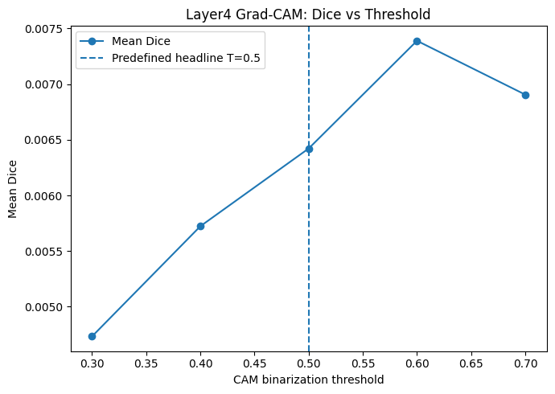

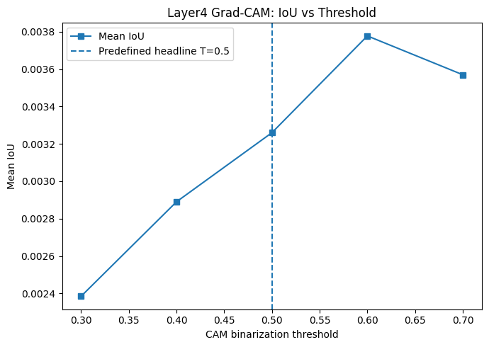

```
NOTE:
Threshold 0.5 remains the predefined headline threshold. The sweep is sensitivity analysis; the empirically strongest test-set threshold is not treated as an independently validated selection.
```

```python
# ============================================================
# CELL 16 — THRESHOLD SENSITIVITY
# ============================================================

threshold_rows = []

for threshold in CAM_THRESHOLDS:

    dice_values = (
        localization_df[
            f"dice_t{threshold}"
        ]
    )

    iou_values = (
        localization_df[
            f"iou_t{threshold}"
        ]
    )

    fraction_values = (
        localization_df[
            f"cam_fraction_t{threshold}"
        ]
    )

    threshold_rows.append({
        "threshold":
            threshold,

        "mean_dice":
            float(dice_values.mean()),

        "median_dice":
            float(dice_values.median()),

        "mean_iou":
            float(iou_values.mean()),

        "median_iou":
            float(iou_values.median()),

        "mean_cam_fraction":
            float(fraction_values.mean()),

        "median_cam_fraction":
            float(fraction_values.median()),
    })


threshold_sensitivity_df = pd.DataFrame(
    threshold_rows
)

threshold_sensitivity_df.to_csv(
    OUTPUT_DIR / "threshold_sensitivity.csv",
    index=False
)

print(
    threshold_sensitivity_df.to_string(
        index=False
    )
)


# ----------------------------------------------------------------
# Mean Dice plot
# ----------------------------------------------------------------

plt.figure(
    figsize=(7, 5)
)

plt.plot(
    threshold_sensitivity_df["threshold"],
    threshold_sensitivity_df["mean_dice"],
    marker="o",
    label="Mean Dice"
)

plt.axvline(
    HEADLINE_CAM_THRESHOLD,
    linestyle="--",
    label=(
        f"Predefined headline "
        f"T={HEADLINE_CAM_THRESHOLD}"
    )
)

plt.xlabel(
    "CAM binarization threshold"
)

plt.ylabel(
    "Mean Dice"
)

plt.title(
    "Layer4 Grad-CAM: Dice vs Threshold"
)

plt.legend()

plt.tight_layout()

plt.savefig(
    OUTPUT_DIR / "threshold_dice.png",
    dpi=300,
    bbox_inches="tight"
)

plt.show()


# ----------------------------------------------------------------
# Mean IoU plot
# ----------------------------------------------------------------

plt.figure(
    figsize=(7, 5)
)

plt.plot(
    threshold_sensitivity_df["threshold"],
    threshold_sensitivity_df["mean_iou"],
    marker="s",
    label="Mean IoU"
)

plt.axvline(
    HEADLINE_CAM_THRESHOLD,
    linestyle="--",
    label=(
        f"Predefined headline "
        f"T={HEADLINE_CAM_THRESHOLD}"
    )
)

plt.xlabel(
    "CAM binarization threshold"
)

plt.ylabel(
    "Mean IoU"
)

plt.title(
    "Layer4 Grad-CAM: IoU vs Threshold"
)

plt.legend()

plt.tight_layout()

plt.savefig(
    OUTPUT_DIR / "threshold_iou.png",
    dpi=300,
    bbox_inches="tight"
)

plt.show()


print(
    "\nNOTE:"
)

print(
    "Threshold 0.5 remains the predefined headline "
    "threshold. The sweep is sensitivity analysis; "
    "the empirically strongest test-set threshold is "
    "not treated as an independently validated selection."
)
```

## Cell 17 — All PDAC cases vs. correctly-predicted PDAC cases (secondary subset, no misclassified cases dropped from primary analysis)

```python
# ============================================================
# CELL 17 — ALL PDAC vs CORRECTLY PREDICTED PDAC
# ============================================================

merged_df = (
    localization_df
    .merge(
        baseline_df[
            [
                "study_id",
                "probability",
                "predicted_label",
                "correct",
            ]
        ],
        on="study_id",
        how="left",
        validate="one_to_one",
    )
    .merge(
        null_df[
            [
                "study_id",
                "percentile_beaten",
            ]
        ],
        on="study_id",
        how="left",
        validate="one_to_one",
    )
)


correctly_predicted = (
    merged_df[
        merged_df["correct"] == True
    ]
)


group_records = []

for group_name, group_df in [
    (
        "all_pdac",
        merged_df
    ),
    (
        "correctly_predicted_pdac",
        correctly_predicted
    ),
]:

    group_records.append({

        "group":
            group_name,

        "n":
            int(len(group_df)),

        "dice_mean":
            float(
                group_df[
                    f"dice_t{HEADLINE_CAM_THRESHOLD}"
                ].mean()
            ),

        "dice_median":
            float(
                group_df[
                    f"dice_t{HEADLINE_CAM_THRESHOLD}"
                ].median()
            ),

        "iou_mean":
            float(
                group_df[
                    f"iou_t{HEADLINE_CAM_THRESHOLD}"
                ].mean()
            ),

        "iou_median":
            float(
                group_df[
                    f"iou_t{HEADLINE_CAM_THRESHOLD}"
                ].median()
            ),

        "pointing_game_rate":
            float(
                group_df[
                    "pointing_game_hit"
                ].mean()
            ),

        "percentile_beaten_mean":
            float(
                group_df[
                    "percentile_beaten"
                ].mean()
            ),

        "percentile_beaten_median":
            float(
                group_df[
                    "percentile_beaten"
                ].median()
            ),

        "peak_distance_mm_mean":
            float(
                group_df[
                    "peak_distance_mm"
                ].mean()
            ),

        "peak_distance_mm_median":
            float(
                group_df[
                    "peak_distance_mm"
                ].median()
            ),

        "mean_prediction_probability":
            float(
                group_df[
                    "probability"
                ].mean()
            ),
    })


prediction_group_df = pd.DataFrame(
    group_records
)

prediction_group_df.to_csv(
    OUTPUT_DIR
    / "prediction_group_comparison.csv",
    index=False
)


print("=" * 70)
print(
    "ALL PDAC vs CORRECTLY PREDICTED PDAC"
)
print("=" * 70)

print(
    prediction_group_df.to_string(
        index=False
    )
)

print(
    "\nThe all-PDAC row is the primary "
    "localization population."
)

print(
    "The correctly-predicted row is a "
    "secondary analysis only."
)
```

```
======================================================================
ALL PDAC vs CORRECTLY PREDICTED PDAC
======================================================================
                   group   n  dice_mean  dice_median  iou_mean  iou_median  pointing_game_rate  percentile_beaten_mean  percentile_beaten_median  peak_distance_mm_mean  peak_distance_mm_median  mean_prediction_probability
                all_pdac 103   0.006421     0.000000   0.00326    0.000000                 0.0                0.585485                    0.6100             102.457267               100.329457                     0.635644
correctly_predicted_pdac  71   0.008171     0.001182   0.00415    0.000592                 0.0                0.618275                    0.6605              96.155980                96.927808                     0.865807

The all-PDAC row is the primary localization population.
The correctly-predicted row is a secondary analysis only.
```

## Cell 18 — Confidence vs. localization (exploratory, correlational)

```
           metric   n  spearman_r  spearman_p  pearson_r  pearson_p
             dice 103    0.286467    0.003351   0.199154   0.043719
percentile_beaten 103    0.172062    0.082226   0.190212   0.054294
 peak_distance_mm 103   -0.207195    0.035730  -0.225454   0.022036
```

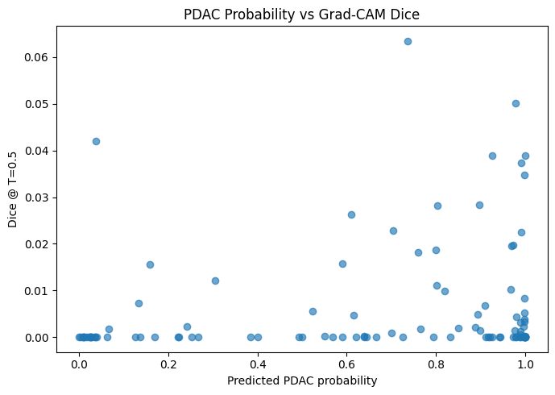

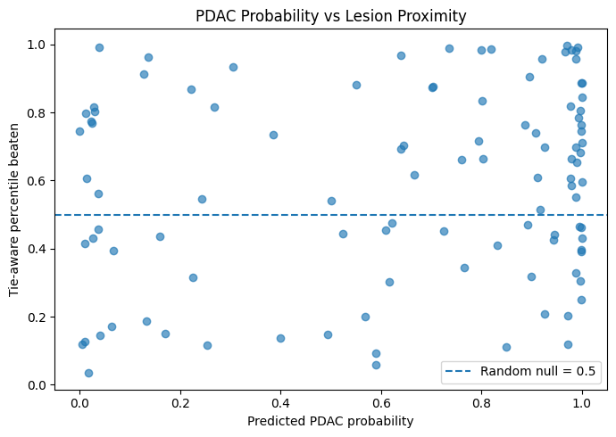

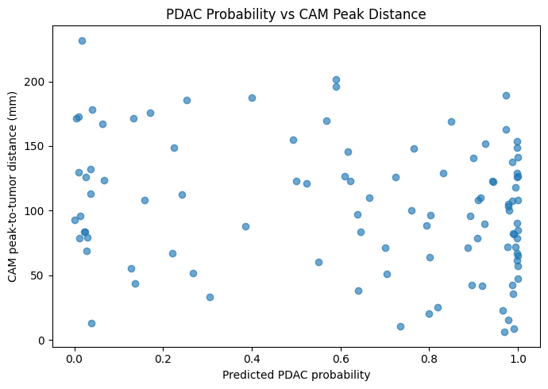

```
This analysis is correlational only and does not establish causal explanation faithfulness.
```

```python
# ============================================================
# CELL 18 — CONFIDENCE VS LOCALIZATION
# ============================================================

confidence_df = merged_df[
    [
        "study_id",
        "probability",
        f"dice_t{HEADLINE_CAM_THRESHOLD}",
        "percentile_beaten",
        "peak_distance_mm",
    ]
].dropna()


confidence_df = confidence_df.rename(
    columns={
        "probability":
            "pdac_probability",

        f"dice_t{HEADLINE_CAM_THRESHOLD}":
            "dice",

        "percentile_beaten":
            "percentile_beaten",

        "peak_distance_mm":
            "peak_distance_mm",
    }
)


correlation_rows = []

for metric_name, y_values in [

    (
        "dice",
        confidence_df["dice"]
    ),

    (
        "percentile_beaten",
        confidence_df["percentile_beaten"]
    ),

    (
        "peak_distance_mm",
        confidence_df["peak_distance_mm"]
    ),
]:

    x_values = (
        confidence_df[
            "pdac_probability"
        ]
    )

    x = x_values.to_numpy(
        dtype=float
    )

    y = y_values.to_numpy(
        dtype=float
    )

    spearman = stats.spearmanr(
        x,
        y
    )

    pearson = stats.pearsonr(
        x,
        y
    )

    correlation_rows.append({

        "metric":
            metric_name,

        "n":
            len(x),

        "spearman_r":
            float(
                spearman.statistic
            ),

        "spearman_p":
            float(
                spearman.pvalue
            ),

        "pearson_r":
            float(
                pearson.statistic
            ),

        "pearson_p":
            float(
                pearson.pvalue
            ),
    })


correlation_df = pd.DataFrame(
    correlation_rows
)

correlation_df.to_csv(
    OUTPUT_DIR
    / "confidence_localization_correlations.csv",
    index=False
)


print(
    correlation_df.to_string(
        index=False
    )
)


# ----------------------------------------------------------------
# Confidence vs Dice
# ----------------------------------------------------------------

plt.figure(
    figsize=(7, 5)
)

plt.scatter(
    confidence_df["pdac_probability"],
    confidence_df["dice"],
    alpha=0.65
)

plt.xlabel(
    "Predicted PDAC probability"
)

plt.ylabel(
    f"Dice @ T={HEADLINE_CAM_THRESHOLD}"
)

plt.title(
    "PDAC Probability vs Grad-CAM Dice"
)

plt.tight_layout()

plt.savefig(
    OUTPUT_DIR / "confidence_vs_dice.png",
    dpi=300,
    bbox_inches="tight"
)

plt.show()


# ----------------------------------------------------------------
# Confidence vs percentile
# ----------------------------------------------------------------

plt.figure(
    figsize=(7, 5)
)

plt.scatter(
    confidence_df["pdac_probability"],
    confidence_df["percentile_beaten"],
    alpha=0.65
)

plt.axhline(
    0.5,
    linestyle="--",
    label="Random null = 0.5"
)

plt.xlabel(
    "Predicted PDAC probability"
)

plt.ylabel(
    "Tie-aware percentile beaten"
)

plt.title(
    "PDAC Probability vs Lesion Proximity"
)

plt.legend()

plt.tight_layout()

plt.savefig(
    OUTPUT_DIR / "confidence_vs_percentile.png",
    dpi=300,
    bbox_inches="tight"
)

plt.show()


# ----------------------------------------------------------------
# Confidence vs peak distance
# ----------------------------------------------------------------

plt.figure(
    figsize=(7, 5)
)

plt.scatter(
    confidence_df["pdac_probability"],
    confidence_df["peak_distance_mm"],
    alpha=0.65
)

plt.xlabel(
    "Predicted PDAC probability"
)

plt.ylabel(
    "CAM peak-to-tumor distance (mm)"
)

plt.title(
    "PDAC Probability vs CAM Peak Distance"
)

plt.tight_layout()

plt.savefig(
    OUTPUT_DIR / "confidence_vs_peak_distance.png",
    dpi=300,
    bbox_inches="tight"
)

plt.show()


print(
    "\nThis analysis is correlational only and "
    "does not establish causal explanation faithfulness."
)
```

## Cell 19 — Randomized-weight model control (negative control)

A freshly, randomly initialized copy of the identical architecture -- built in memory only, never saved to disk, never overwriting the trained checkpoint. If the trained model's localization signal (Cell 13) is genuinely learned rather than a trivial artifact of the architecture, cropping geometry, or Grad-CAM's own mechanics, the randomized model should show no such signal.

```python
# ============================================================
# CELL 19 — RANDOMIZED-WEIGHT MODEL CONTROL
# ============================================================

model_random = (
    build_model()
    .to(DEVICE)
)

model_random.eval()

gradcam_random = GradCAM3D(
    model_random,
    model_random.layer4
)

random_control_rows = []

random_failure_rows = []

seed_lookup = (
    case_seed_df
    .set_index("study_id")["case_seed"]
    .to_dict()
)


print(
    f"Running randomized-model control "
    f"on {len(valid_cases)} cases..."
)


for i, study_id in enumerate(
    valid_cases
):

    row = pdac_test_df[
        pdac_test_df["study_id"] == study_id
    ].iloc[0]

    volume, tumor_mask = load_volume_and_mask(
        row,
        DATASET_DIR
    )

    volume_tensor = (
        torch.from_numpy(
            volume.copy()
        )
        .float()
        .unsqueeze(0)
        .unsqueeze(0)
        .to(DEVICE)
    )

    cam_r, prob_r, status_r, diag_r = (
        gradcam_random.generate(
            volume_tensor
        )
    )

    if status_r != "ok":

        random_failure_rows.append({

            "study_id":
                study_id,

            "status":
                status_r,

            "reason":
                diag_r.get(
                    "reason",
                    ""
                ),
        })

        del volume_tensor

        continue


    voxel_dist_map = (
        distance_transform_edt(
            ~tumor_mask
        )
    )

    physical_dist_map = (
        distance_transform_edt(
            ~tumor_mask,
            sampling=KNOWN_SPACING_ZYX_MM
        )
    )


    # EXACT SAME CASE SEED AND RANDOM DRAW
    # as the trained model analysis.

    case_seed = int(
        seed_lookup[study_id]
    )

    rng = np.random.default_rng(
        case_seed
    )

    D, H, W = tumor_mask.shape

    random_points = np.column_stack([
        rng.integers(
            0,
            D,
            size=N_RANDOM_POINTS_PER_CASE
        ),
        rng.integers(
            0,
            H,
            size=N_RANDOM_POINTS_PER_CASE
        ),
        rng.integers(
            0,
            W,
            size=N_RANDOM_POINTS_PER_CASE
        ),
    ])

    rz = random_points[:, 0]
    ry = random_points[:, 1]
    rx = random_points[:, 2]

    random_dist_mm = physical_dist_map[
        rz, ry, rx
    ]


    peak_index = np.unravel_index(
        np.argmax(cam_r),
        cam_r.shape
    )

    actual_dist_mm = float(
        physical_dist_map[
            peak_index
        ]
    )

    actual_dist_vox = float(
        voxel_dist_map[
            peak_index
        ]
    )

    pct_beaten = tie_aware_percentile(
        actual_dist_mm,
        random_dist_mm
    )

    pointing_hit = bool(
        tumor_mask[
            peak_index
        ]
    )


    random_control_rows.append({

        "study_id":
            study_id,

        "patient_id":
            row["patient_id"],

        "case_seed":
            case_seed,

        "cam_status":
            status_r,

        "random_model_probability":
            float(prob_r),

        "peak_distance_voxels":
            actual_dist_vox,

        "peak_distance_mm":
            actual_dist_mm,

        "percentile_beaten":
            pct_beaten,

        "pointing_game_hit":
            pointing_hit,
    })


    del volume_tensor

    if (
        (i + 1) % 20 == 0
        or (i + 1) == len(valid_cases)
    ):
        print(
            f"  {i + 1}/{len(valid_cases)}"
        )


gradcam_random.remove_hooks()

del model_random


random_control_df = pd.DataFrame(
    random_control_rows
)

random_failures_df = pd.DataFrame(
    random_failure_rows
)


random_control_df.to_csv(
    OUTPUT_DIR
    / "randomized_model_control.csv",
    index=False
)

random_failures_df.to_csv(
    OUTPUT_DIR
    / "randomized_model_control_failures.csv",
    index=False
)


# ----------------------------------------------------------------
# Matched trained-vs-randomized cases.
# ----------------------------------------------------------------

trained_df = null_df[
    [
        "study_id",
        "percentile_beaten",
        "actual_distance_mm",
    ]
].rename(
    columns={
        "percentile_beaten":
            "trained_percentile_beaten",

        "actual_distance_mm":
            "trained_distance_mm",
    }
)


random_df = random_control_df[
    [
        "study_id",
        "percentile_beaten",
        "peak_distance_mm",
    ]
].rename(
    columns={
        "percentile_beaten":
            "randomized_percentile_beaten",

        "peak_distance_mm":
            "randomized_distance_mm",
    }
)


randomized_paired = trained_df.merge(
    random_df,
    on="study_id",
    how="inner",
    validate="one_to_one"
)


print("\n" + "=" * 70)
print("RANDOMIZED-MODEL CONTROL — SAMPLE COUNTS")
print("=" * 70)

print(
    "Trained valid cases     :",
    len(trained_df)
)

print(
    "Randomized valid cases  :",
    len(random_control_df)
)

print(
    "Randomized failures     :",
    len(random_failures_df)
)

print(
    "Paired valid cases      :",
    len(randomized_paired)
)


# ----------------------------------------------------------------
# Paired percentile comparison.
# ----------------------------------------------------------------

trained_pct = (
    randomized_paired[
        "trained_percentile_beaten"
    ]
    .to_numpy(dtype=float)
)

random_pct = (
    randomized_paired[
        "randomized_percentile_beaten"
    ]
    .to_numpy(dtype=float)
)

pct_diff = (
    trained_pct
    - random_pct
)


if len(pct_diff) == 0:

    pct_stat = np.nan
    pct_p = np.nan

else:

    if np.allclose(
        pct_diff,
        0
    ):

        pct_stat = np.nan
        pct_p = 1.0

    else:

        result_pct = stats.wilcoxon(
            pct_diff,
            alternative="two-sided"
        )

        pct_stat = float(
            result_pct.statistic
        )

        pct_p = float(
            result_pct.pvalue
        )


# ----------------------------------------------------------------
# Paired physical-distance comparison.
# ----------------------------------------------------------------

trained_dist = (
    randomized_paired[
        "trained_distance_mm"
    ]
    .to_numpy(dtype=float)
)

random_dist = (
    randomized_paired[
        "randomized_distance_mm"
    ]
    .to_numpy(dtype=float)
)

dist_diff = (
    trained_dist
    - random_dist
)


if len(dist_diff) == 0:

    dist_stat = np.nan
    dist_p = np.nan

else:

    if np.allclose(
        dist_diff,
        0
    ):

        dist_stat = np.nan
        dist_p = 1.0

    else:

        result_dist = stats.wilcoxon(
            dist_diff,
            alternative="two-sided"
        )

        dist_stat = float(
            result_dist.statistic
        )

        dist_p = float(
            result_dist.pvalue
        )


control_stats = {

    "trained_valid_n":
        int(len(trained_df)),

    "randomized_valid_n":
        int(len(random_control_df)),

    "randomized_failure_n":
        int(len(random_failures_df)),

    "paired_n":
        int(len(randomized_paired)),

    "trained_percentile_mean":
        float(
            trained_pct.mean()
        )
        if len(trained_pct)
        else np.nan,

    "trained_percentile_median":
        float(
            np.median(trained_pct)
        )
        if len(trained_pct)
        else np.nan,

    "randomized_percentile_mean":
        float(
            random_pct.mean()
        )
        if len(random_pct)
        else np.nan,

    "randomized_percentile_median":
        float(
            np.median(random_pct)
        )
        if len(random_pct)
        else np.nan,

    "mean_paired_percentile_difference":
        float(
            pct_diff.mean()
        )
        if len(pct_diff)
        else np.nan,

    "median_paired_percentile_difference":
        float(
            np.median(pct_diff)
        )
        if len(pct_diff)
        else np.nan,

    "n_trained_percentile_gt_random":
        int(
            (pct_diff > 0).sum()
        ),

    "n_random_percentile_gt_trained":
        int(
            (pct_diff < 0).sum()
        ),

    "n_percentile_ties":
        int(
            (pct_diff == 0).sum()
        ),

    "percentile_wilcoxon_stat":
        pct_stat,

    "percentile_wilcoxon_p":
        pct_p,

    "trained_distance_mean_mm":
        float(
            trained_dist.mean()
        )
        if len(trained_dist)
        else np.nan,

    "randomized_distance_mean_mm":
        float(
            random_dist.mean()
        )
        if len(random_dist)
        else np.nan,

    "mean_paired_distance_difference_mm":
        float(
            dist_diff.mean()
        )
        if len(dist_diff)
        else np.nan,

    "median_paired_distance_difference_mm":
        float(
            np.median(dist_diff)
        )
        if len(dist_diff)
        else np.nan,

    "distance_wilcoxon_stat":
        dist_stat,

    "distance_wilcoxon_p":
        dist_p,
}


print("\n" + "=" * 70)
print("RANDOMIZED-WEIGHT MODEL CONTROL")
print("=" * 70)

for key, value in (
    control_stats.items()
):

    print(
        f"{key}: {value}"
    )


print(
    "\nInterpretation:"
)

print(
    "A trained-vs-randomized difference strengthens "
    "the case that the observed localization signal "
    "is not solely explained by architecture/geometry. "
    "It does not establish causal explanation faithfulness."
)


with open(
    OUTPUT_DIR
    / "randomized_model_control_statistics.json",
    "w"
) as f:

    json.dump(
        control_stats,
        f,
        indent=2
    )


print(
    "\nSaved:",
    OUTPUT_DIR
    / "randomized_model_control.csv"
)

print(
    "Saved:",
    OUTPUT_DIR
    / "randomized_model_control_failures.csv"
)

print(
    "Saved:",
    OUTPUT_DIR
    / "randomized_model_control_statistics.json"
)
```

```
Running randomized-model control on 103 cases...
  20/103
  40/103
  60/103
  80/103
  100/103
  103/103

======================================================================
RANDOMIZED-MODEL CONTROL — SAMPLE COUNTS
======================================================================
Trained valid cases     : 103
Randomized valid cases  : 103
Randomized failures     : 0
Paired valid cases      : 103

======================================================================
RANDOMIZED-WEIGHT MODEL CONTROL
======================================================================
trained_valid_n: 103
randomized_valid_n: 103
randomized_failure_n: 0
paired_n: 103
trained_percentile_mean: 0.585485436893204
trained_percentile_median: 0.61
randomized_percentile_mean: 0.6021432038834951
randomized_percentile_median: 0.575
mean_paired_percentile_difference: -0.016657766990291267
median_paired_percentile_difference: 0.034499999999999975
n_trained_percentile_gt_random: 53
n_random_percentile_gt_trained: 50
n_percentile_ties: 0
percentile_wilcoxon_stat: 2561.0
percentile_wilcoxon_p: 0.7002961330087741
trained_distance_mean_mm: 102.45726722182894
randomized_distance_mean_mm: 99.90714595422666
mean_paired_distance_difference_mm: 2.5501212676023144
median_paired_distance_difference_mm: -5.294416937693711
distance_wilcoxon_stat: 2596.0
distance_wilcoxon_p: 0.7873346391666816

Interpretation:
A trained-vs-randomized difference strengthens the case that the observed localization signal is not solely explained by architecture/geometry. It does not establish causal explanation faithfulness.

Saved: /kaggle/working/gradcam_investigation/randomized_model_control.csv
Saved: /kaggle/working/gradcam_investigation/randomized_model_control_failures.csv
Saved: /kaggle/working/gradcam_investigation/randomized_model_control_statistics.json
```

## Cell 20 — Qualitative visualization (six selected cases)

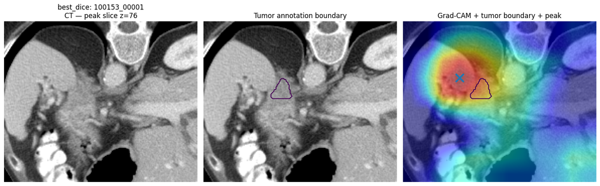

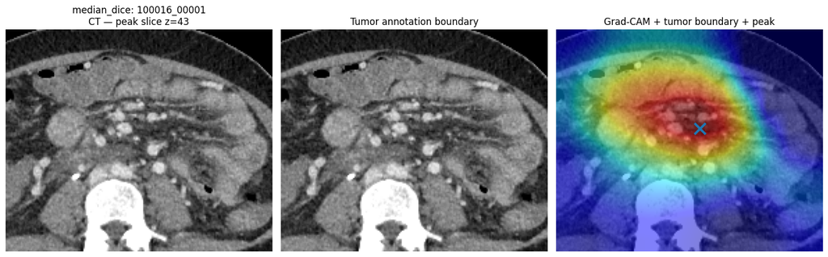

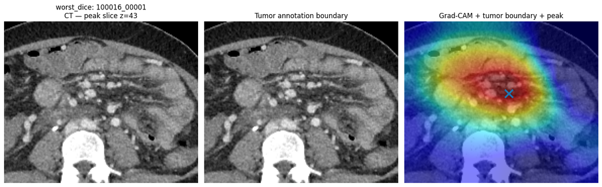

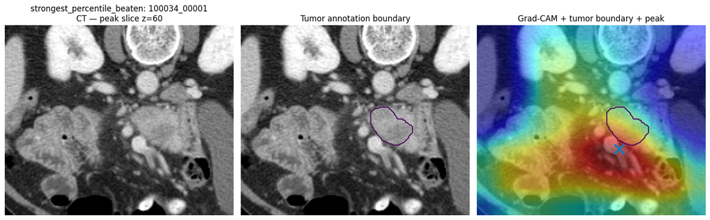

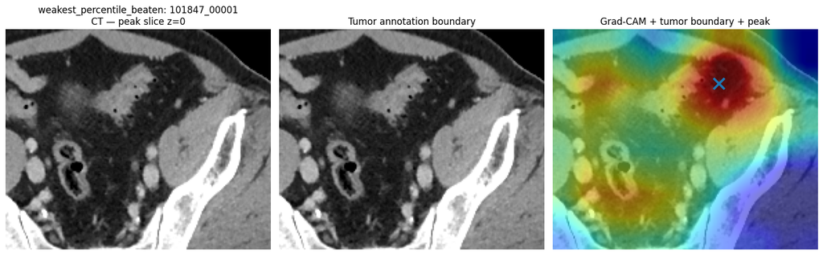

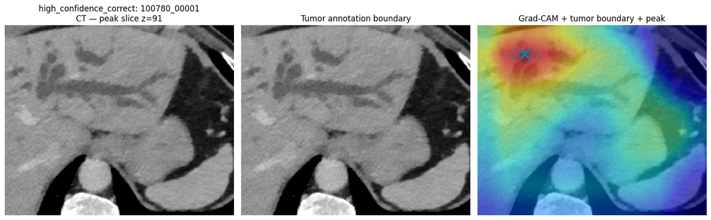

```
✓ Qualitative figures saved to: /kaggle/working/gradcam_investigation/qualitative
✓ No Grad-CAM was recomputed in this cell.
```

```python
# ============================================================
# CELL 20 — QUALITATIVE VISUALIZATION
# ============================================================

QUAL_DIR = (
    OUTPUT_DIR
    / "qualitative"
)

QUAL_DIR.mkdir(
    parents=True,
    exist_ok=True
)


def select_closest_to_value(
    df,
    column,
    value
):
    distances = (
        df[column]
        - value
    ).abs()

    return df.loc[
        distances.idxmin()
    ]


dice_column = (
    f"dice_t{HEADLINE_CAM_THRESHOLD}"
)

valid_visual_df = (
    merged_df
    .dropna(
        subset=[
            dice_column,
            "percentile_beaten",
            "probability",
            "peak_distance_mm",
        ]
    )
    .copy()
)


median_dice = (
    valid_visual_df[
        dice_column
    ].median()
)


correct_df = valid_visual_df[
    valid_visual_df["correct"] == True
]


selections = {

    "best_dice":
        valid_visual_df.loc[
            valid_visual_df[
                dice_column
            ].idxmax()
        ],

    "median_dice":
        select_closest_to_value(
            valid_visual_df,
            dice_column,
            median_dice
        ),

    "worst_dice":
        valid_visual_df.loc[
            valid_visual_df[
                dice_column
            ].idxmin()
        ],

    "strongest_percentile_beaten":
        valid_visual_df.loc[
            valid_visual_df[
                "percentile_beaten"
            ].idxmax()
        ],

    "weakest_percentile_beaten":
        valid_visual_df.loc[
            valid_visual_df[
                "percentile_beaten"
            ].idxmin()
        ],
}


# Representative high-confidence correct case.
if len(correct_df) > 0:

    representative = correct_df.loc[
        correct_df["probability"].idxmax()
    ]

    selections[
        "high_confidence_correct"
    ] = representative


selection_records = []


for label, selected_row in (
    selections.items()
):

    study_id = selected_row[
        "study_id"
    ]

    cam_path = (
        OUTPUT_DIR
        / "cams_layer4"
        / f"{study_id}.npy"
    )

    assert cam_path.exists(), (
        f"Saved layer4 CAM missing for "
        f"{study_id}: {cam_path}"
    )


    full_row = pdac_test_df[
        pdac_test_df[
            "study_id"
        ] == study_id
    ].iloc[0]


    volume, tumor_mask = (
        load_volume_and_mask(
            full_row,
            DATASET_DIR
        )
    )


    cam = np.load(
        cam_path
    )


    assert (
        cam.shape
        == tumor_mask.shape
    )


    peak_index = np.unravel_index(
        np.argmax(cam),
        cam.shape
    )

    z = int(
        peak_index[0]
    )


    fig, axes = plt.subplots(
        1,
        3,
        figsize=(15, 5)
    )


    # CT
    axes[0].imshow(
        volume[z],
        cmap="gray"
    )

    axes[0].set_title(
        f"{label}: {study_id}\n"
        f"CT — peak slice z={z}"
    )

    axes[0].axis("off")


    # Tumor boundary
    axes[1].imshow(
        volume[z],
        cmap="gray"
    )

    if tumor_mask[z].any():

        axes[1].contour(
            tumor_mask[z].astype(float),
            levels=[0.5],
            linewidths=1.5
        )

    axes[1].set_title(
        "Tumor annotation boundary"
    )

    axes[1].axis("off")


    # CAM overlay
    axes[2].imshow(
        volume[z],
        cmap="gray"
    )

    axes[2].imshow(
        cam[z],
        cmap="jet",
        alpha=0.5
    )

    if tumor_mask[z].any():

        axes[2].contour(
            tumor_mask[z].astype(float),
            levels=[0.5],
            linewidths=1.5
        )

    axes[2].plot(
        peak_index[2],
        peak_index[1],
        marker="x",
        markersize=14,
        markeredgewidth=3
    )

    axes[2].set_title(
        "Grad-CAM + tumor boundary + peak"
    )

    axes[2].axis("off")


    plt.tight_layout()

    output_path = (
        QUAL_DIR
        / f"{label}_{study_id}.png"
    )

    plt.savefig(
        output_path,
        dpi=300,
        bbox_inches="tight"
    )

    plt.show()
    plt.close(fig)


    selection_records.append({

        "selection_type":
            label,

        "study_id":
            study_id,

        "patient_id":
            selected_row["patient_id"],

        "dice":
            float(
                selected_row[dice_column]
            ),

        "iou":
            float(
                selected_row[
                    f"iou_t{HEADLINE_CAM_THRESHOLD}"
                ]
            ),

        "percentile_beaten":
            float(
                selected_row[
                    "percentile_beaten"
                ]
            ),

        "peak_distance_mm":
            float(
                selected_row[
                    "peak_distance_mm"
                ]
            ),

        "probability":
            float(
                selected_row[
                    "probability"
                ]
            ),

        "predicted_label":
            int(
                selected_row[
                    "predicted_label"
                ]
            ),

        "correct":
            bool(
                selected_row[
                    "correct"
                ]
            ),
    })


qualitative_selection_df = pd.DataFrame(
    selection_records
)

qualitative_selection_df.to_csv(
    OUTPUT_DIR
    / "qualitative_case_selection.csv",
    index=False
)


print(
    "\n✓ Qualitative figures saved to:",
    QUAL_DIR
)

print(
    "✓ No Grad-CAM was recomputed in this cell."
)
```

## Cell 21 — Failure and edge-case summary (nothing silently excluded)

```python
# ============================================================
# CELL 21 — FAILURE / EDGE CASE ANALYSIS
# ============================================================

print("=" * 70)
print("FAILURE / EDGE-CASE SUMMARY")
print("=" * 70)


# ------------------------------------------------------------
# 1. ROI-boundary case metrics
# ------------------------------------------------------------
#
# Use the primary localization dataframe and random-null dataframe
# directly rather than depending on merged_df from another cell.
# This makes Cell 21 independently executable.
# ------------------------------------------------------------

roi_case_ids = sorted(
    set(ROI_BOUNDARY_CASES)
    & set(localization_df["study_id"])
)

roi_boundary_metrics = []

for study_id in roi_case_ids:

    loc_match = localization_df[
        localization_df["study_id"] == study_id
    ]

    null_match = null_df[
        null_df["study_id"] == study_id
    ]

    if len(loc_match) == 0:
        continue

    loc_row = loc_match.iloc[0]

    record = {
        "study_id": study_id,
        "dice_t0.5": float(
            loc_row[f"dice_t{HEADLINE_CAM_THRESHOLD}"]
        ),
        "iou_t0.5": float(
            loc_row[f"iou_t{HEADLINE_CAM_THRESHOLD}"]
        ),
        "pointing_game_hit": bool(
            loc_row["pointing_game_hit"]
        ),
        "peak_distance_voxels": float(
            loc_row["peak_distance_voxels"]
        ),
        "peak_distance_mm": float(
            loc_row["peak_distance_mm"]
        ),
    }

    if len(null_match) > 0:
        null_row = null_match.iloc[0]

        record.update({
            "percentile_beaten": float(
                null_row["percentile_beaten"]
            ),
            "normalized_distance": float(
                null_row["normalized_distance"]
            ),
            "case_seed": int(
                null_row["case_seed"]
            ),
        })
    else:
        record.update({
            "percentile_beaten": np.nan,
            "normalized_distance": np.nan,
            "case_seed": np.nan,
        })

    roi_boundary_metrics.append(record)


# ------------------------------------------------------------
# 2. CAM failure counts
# ------------------------------------------------------------

invalid_cams = int(
    (
        layer4_status_df["cam_status"]
        == "invalid"
    ).sum()
)

degenerate_cams = int(
    (
        layer4_status_df["cam_status"]
        == "degenerate"
    ).sum()
)

valid_cams = int(
    (
        layer4_status_df["cam_status"]
        == "ok"
    ).sum()
)


# ------------------------------------------------------------
# 3. Input-audit counts
# ------------------------------------------------------------

shape_mismatch_count = len(
    shape_mismatches
)

unexpected_label_count = len(
    bad_labels
)

zero_lesion_count = len(
    zero_lesion_pdac
)


# ------------------------------------------------------------
# 4. Print ROI cases
# ------------------------------------------------------------

print("\nKnown ROI-boundary cases:")

if roi_boundary_metrics:

    roi_df = pd.DataFrame(
        roi_boundary_metrics
    )

    print(
        roi_df.to_string(
            index=False
        )
    )

    roi_df.to_csv(
        OUTPUT_DIR / "roi_boundary_case_metrics.csv",
        index=False
    )

else:

    print(
        "None of the known ROI-boundary cases "
        "are present in the analyzed PDAC test set."
    )


# ------------------------------------------------------------
# 5. Final failure summary
# ------------------------------------------------------------

failure_summary = {
    "layer4_valid_cams": valid_cams,
    "layer4_invalid_cams": invalid_cams,
    "layer4_degenerate_cams": degenerate_cams,

    "shape_mismatches_test_set":
        shape_mismatch_count,

    "unexpected_labels":
        unexpected_label_count,

    "zero_lesion_pdac_cases":
        zero_lesion_count,

    "spacing_source":
        SPACING_SOURCE,

    "known_spacing_zyx_mm":
        list(KNOWN_SPACING_ZYX_MM),

    "roi_boundary_case_metrics":
        roi_boundary_metrics,
}


# ------------------------------------------------------------
# 6. Print summary
# ------------------------------------------------------------

print("\nSummary")
print("-" * 70)

for key, value in failure_summary.items():
    print(
        f"{key}: {value}"
    )


# ------------------------------------------------------------
# 7. Save JSON
# ------------------------------------------------------------

failure_path = (
    OUTPUT_DIR
    / "failure_and_edge_case_summary.json"
)

with open(
    failure_path,
    "w",
    encoding="utf-8"
) as f:

    json.dump(
        failure_summary,
        f,
        indent=2,
        default=str
    )

print(
    "\nSaved:",
    failure_path
)

print("\n✓ Failure/edge-case analysis complete.")
```

```
======================================================================
FAILURE / EDGE-CASE SUMMARY
======================================================================

Known ROI-boundary cases:
None of the known ROI-boundary cases are present in the analyzed PDAC test set.

Summary
----------------------------------------------------------------------
layer4_valid_cams: 103
layer4_invalid_cams: 0
layer4_degenerate_cams: 0
shape_mismatches_test_set: 0
unexpected_labels: 0
zero_lesion_pdac_cases: 0
spacing_source: metadata_columns_found_needs_manual_review
known_spacing_zyx_mm: [3.0, 1.0, 1.0]
roi_boundary_case_metrics: []

Saved: /kaggle/working/gradcam_investigation/failure_and_edge_case_summary.json

✓ Failure/edge-case analysis complete.
```

## Cell 22 — Final summary table

```python
# ============================================================
# CELL 22 — FINAL SUMMARY TABLE
# ============================================================

dice_column = (
    f"dice_t{HEADLINE_CAM_THRESHOLD}"
)

iou_column = (
    f"iou_t{HEADLINE_CAM_THRESHOLD}"
)


final_summary = {

    "dataset": {

        "n_test":
            int(len(test_df)),

        "n_pdac":
            int(len(pdac_test_df)),

        "n_non_pdac":
            int(len(non_pdac_test_df)),
    },


    "model": {

        "checkpoint":
            str(CHECKPOINT_PATH),

        "n_parameters":
            int(n_params),

        "checkpoint_epoch":
            (
                int(checkpoint["epoch"])
                if checkpoint.get("epoch")
                is not None
                else None
            ),

        "best_validation_loss":
            checkpoint.get(
                "best_val_loss"
            ),
    },


    "primary_layer4": {

        "n_valid_cam":
            int(n_ok),

        "dice_mean":
            float(
                localization_df[
                    dice_column
                ].mean()
            ),

        "dice_median":
            float(
                localization_df[
                    dice_column
                ].median()
            ),

        "iou_mean":
            float(
                localization_df[
                    iou_column
                ].mean()
            ),

        "iou_median":
            float(
                localization_df[
                    iou_column
                ].median()
            ),

        "pointing_game_count":
            int(
                localization_df[
                    "pointing_game_hit"
                ].sum()
            ),

        "pointing_game_rate":
            float(
                localization_df[
                    "pointing_game_hit"
                ].mean()
            ),

        "peak_distance_mm_mean":
            float(
                localization_df[
                    "peak_distance_mm"
                ].mean()
            ),

        "peak_distance_mm_median":
            float(
                localization_df[
                    "peak_distance_mm"
                ].median()
            ),

        "percentile_beaten_mean":
            float(
                null_df[
                    "percentile_beaten"
                ].mean()
            ),

        "percentile_beaten_median":
            float(
                null_df[
                    "percentile_beaten"
                ].median()
            ),

        "percentile_beaten_95ci":
            [
                float(
                    pb_bootstrap[
                        "ci_low"
                    ]
                ),
                float(
                    pb_bootstrap[
                        "ci_high"
                    ]
                ),
            ],

        "random_null_wilcoxon_p":
            float(wilcoxon_p),

        "random_null_binomial_p":
            float(
                binom_result.pvalue
            ),
    },


    "layer3_vs_layer4":

        paired_stats,


    "threshold_sensitivity": {

        "headline_threshold":
            HEADLINE_CAM_THRESHOLD,

        "best_mean_dice_threshold_exploratory":
            float(
                threshold_sensitivity_df.loc[
                    threshold_sensitivity_df[
                        "mean_dice"
                    ].idxmax(),
                    "threshold"
                ]
            ),
    },


    "confidence_correlations":
        correlation_df.to_dict(
            orient="records"
        ),


    "randomized_model_control":
        control_stats,


    "roi_boundary_cases":
        roi_boundary_metrics,
}


with open(
    OUTPUT_DIR
    / "final_summary.json",
    "w"
) as f:

    json.dump(
        final_summary,
        f,
        indent=2,
        default=str
    )


final_summary_flat = pd.json_normalize(
    final_summary,
    sep="_"
)

final_summary_flat.to_csv(
    OUTPUT_DIR
    / "final_summary.csv",
    index=False
)


print("=" * 70)
print("FINAL SUMMARY")
print("=" * 70)

print(
    json.dumps(
        final_summary,
        indent=2,
        default=str
    )
)

print(
    "\nSaved:",
    OUTPUT_DIR / "final_summary.json"
)

print(
    "Saved:",
    OUTPUT_DIR / "final_summary.csv"
)
```

```
======================================================================
FINAL SUMMARY
======================================================================
{
  "dataset": {
    "n_test": 337,
    "n_pdac": 103,
    "n_non_pdac": 234
  },
  "model": {
    "checkpoint": "/kaggle/input/datasets/shahriarahmed66/panorama-run2-best-checkpoint/best_model.pt",
    "n_parameters": 33147969,
    "checkpoint_epoch": 4,
    "best_validation_loss": 0.9166195351084881
  },
  "primary_layer4": {
    "n_valid_cam": 103,
    "dice_mean": 0.00642129868806537,
    "dice_median": 0.0,
    "iou_mean": 0.0032603218572421584,
    "iou_median": 0.0,
    "pointing_game_count": 0,
    "pointing_game_rate": 0.0,
    "peak_distance_mm_mean": 102.45726722182894,
    "peak_distance_mm_median": 100.32945728947207,
    "percentile_beaten_mean": 0.585485436893204,
    "percentile_beaten_median": 0.61,
    "percentile_beaten_95ci": [
      0.5314407766990291,
      0.6386839199029127
    ],
    "random_null_wilcoxon_p": 0.0015253536315915687,
    "random_null_binomial_p": 0.03780955379312888
  },
  "layer3_vs_layer4": {
    "percentile_beaten": {
      "metric_unit": "unitless",
      "direction": "layer4_minus_layer3",
      "median_diff": 0.10049999999999992,
      "mean_diff": 0.11613592233009709,
```

[output cut: 72 more lines]

```
    "n_percentile_ties": 0,
    "percentile_wilcoxon_stat": 2561.0,
    "percentile_wilcoxon_p": 0.7002961330087741,
    "trained_distance_mean_mm": 102.45726722182894,
    "randomized_distance_mean_mm": 99.90714595422666,
    "mean_paired_distance_difference_mm": 2.5501212676023144,
    "median_paired_distance_difference_mm": -5.294416937693711,
    "distance_wilcoxon_stat": 2596.0,
    "distance_wilcoxon_p": 0.7873346391666816
  },
  "roi_boundary_cases": []
}

Saved: /kaggle/working/gradcam_investigation/final_summary.json
Saved: /kaggle/working/gradcam_investigation/final_summary.csv
```

## Cell 23 — Automatically generated cautious interpretation

Generated directly from the computed statistics above, using consistently careful language -- not asserted independently of the numbers.

```python
# ============================================================
# CELL 23 — FINAL INTERPRETATION
# ============================================================

lines = []

lines.append(
    "RUN 2 GRAD-CAM LOCALIZATION INVESTIGATION — INTERPRETATION"
)

lines.append(
    "=" * 70
)


# ----------------------------------------------------------------
# Classification
# ----------------------------------------------------------------

test_accuracy = (
    accuracy_score(
        y_true,
        y_pred
    )
)

test_auc = (
    roc_auc_score(
        y_true,
        y_prob
    )
)

lines.append(
    "\nClassification performance:"
)

lines.append(
    f"Accuracy = {test_accuracy:.4f}; "
    f"ROC-AUC = {test_auc:.4f}."
)


# ----------------------------------------------------------------
# Strict localization
# ----------------------------------------------------------------

mean_dice = float(
    localization_df[
        dice_column
    ].mean()
)

pointing_rate = float(
    localization_df[
        "pointing_game_hit"
    ].mean()
)

lines.append(
    "\nStrict layer4 localization:"
)

lines.append(
    f"At the predefined CAM threshold "
    f"T={HEADLINE_CAM_THRESHOLD}, mean Dice = "
    f"{mean_dice:.4f} and Pointing Game rate = "
    f"{pointing_rate:.4f}."
)


# ----------------------------------------------------------------
# Patient-specific null
# ----------------------------------------------------------------

mean_percentile = float(
    null_df[
        "percentile_beaten"
    ].mean()
)

lines.append(
    "\nPatient-specific random-null comparison:"
)

if wilcoxon_p < 0.05:

    lines.append(
        f"The layer4 Grad-CAM peak showed greater "
        f"lesion proximity than patient-specific "
        f"random locations: mean tie-aware percentile "
        f"beaten = {mean_percentile:.4f}, "
        f"Wilcoxon one-sided p = {wilcoxon_p:.6g}."
    )

    lines.append(
        "This is evidence of spatial association "
        "between the saliency peak and the lesion. "
        "It does not establish causal explanation "
        "faithfulness."
    )

else:

    lines.append(
        f"The layer4 Grad-CAM peak did not show "
        f"statistically significant greater lesion "
        f"proximity than patient-specific random "
        f"locations: p = {wilcoxon_p:.6g}."
    )


# ----------------------------------------------------------------
# Layer comparison
# ----------------------------------------------------------------

layer_pct = (
    paired_stats[
        "percentile_beaten"
    ]
)

layer_dist = (
    paired_stats[
        "peak_distance_mm"
    ]
)

lines.append(
    "\nLayer sensitivity:"
)

lines.append(
    f"The paired layer4-vs-layer3 test for "
    f"percentile beaten gave p = "
    f"{layer_pct['wilcoxon_p']:.6g}, with median "
    f"layer4-minus-layer3 difference = "
    f"{layer_pct['median_diff']:+.4f}."
)

lines.append(
    f"For physical peak-to-tumor distance, the "
    f"paired test gave p = "
    f"{layer_dist['wilcoxon_p']:.6g}, with median "
    f"layer4-minus-layer3 difference = "
    f"{layer_dist['median_diff']:+.4f} mm."
)

lines.append(
    "These paired results indicate whether the "
    "localization statistic depends on network depth; "
    "they should not be interpreted as proof that one "
    "layer uniquely represents the model's reasoning."
)


# ----------------------------------------------------------------
# Randomized model
# ----------------------------------------------------------------

control_p = (
    control_stats[
        "percentile_wilcoxon_p"
    ]
)

lines.append(
    "\nRandomized-weight control:"
)

lines.append(
    f"The trained-vs-randomized paired comparison "
    f"used {control_stats['paired_n']} matched cases. "
    f"The percentile-beaten paired p-value was "
    f"{control_p:.6g}."
)

if (
    np.isfinite(control_p)
    and control_p < 0.05
):

    lines.append(
        "The trained and randomized models therefore "
        "showed distinguishable localization behavior "
        "under this control, strengthening the argument "
        "that the observed signal is not explained solely "
        "by architecture/geometry."
    )

else:

    lines.append(
        "The randomized-weight control did not show a "
        "statistically significant trained-vs-randomized "
        "difference under the percentile-beaten metric."
    )

lines.append(
    "This control is supplementary and does not by "
    "itself establish causal explanation faithfulness."
)


# ----------------------------------------------------------------
# Interpret poor overlap correctly
# ----------------------------------------------------------------

lines.append(
    "\nRelationship between overlap and proximity:"
)

lines.append(
    "Pointing Game and Dice require the saliency "
    "representation to fall directly within the "
    "annotated lesion, whereas peak-to-tumor distance "
    "asks how close the saliency peak is to the lesion. "
    "A broad CAM can therefore have weak overlap while "
    "still showing greater lesion proximity than random "
    "locations."
)


interpretation_text = "\n".join(
    lines
)

print(
    interpretation_text
)


with open(
    OUTPUT_DIR / "interpretation.txt",
    "w"
) as f:

    f.write(
        interpretation_text
    )

print(
    "\nSaved:",
    OUTPUT_DIR
    / "interpretation.txt"
)
```

```
RUN 2 GRAD-CAM LOCALIZATION INVESTIGATION — INTERPRETATION
======================================================================

Classification performance:
Accuracy = 0.8101; ROC-AUC = 0.8556.

Strict layer4 localization:
At the predefined CAM threshold T=0.5, mean Dice = 0.0064 and Pointing Game rate = 0.0000.

Patient-specific random-null comparison:
The layer4 Grad-CAM peak showed greater lesion proximity than patient-specific random locations: mean tie-aware percentile beaten = 0.5855, Wilcoxon one-sided p = 0.00152535.
This is evidence of spatial association between the saliency peak and the lesion. It does not establish causal explanation faithfulness.

Layer sensitivity:
The paired layer4-vs-layer3 test for percentile beaten gave p = 0.001623, with median layer4-minus-layer3 difference = +0.1005.
For physical peak-to-tumor distance, the paired test gave p = 0.000572022, with median layer4-minus-layer3 difference = -17.2288 mm.
These paired results indicate whether the localization statistic depends on network depth; they should not be interpreted as proof that one layer uniquely represents the model's reasoning.

Randomized-weight control:
The trained-vs-randomized paired comparison used 103 matched cases. The percentile-beaten paired p-value was 0.700296.
The randomized-weight control did not show a statistically significant trained-vs-randomized difference under the percentile-beaten metric.
This control is supplementary and does not by itself establish causal explanation faithfulness.

Relationship between overlap and proximity:
Pointing Game and Dice require the saliency representation to fall directly within the annotated lesion, whereas peak-to-tumor distance asks how close the saliency peak is to the lesion. A broad CAM can therefore have weak overlap while still showing greater lesion proximity than random locations.

Saved: /kaggle/working/gradcam_investigation/interpretation.txt
```

## Cell 24 — Reproducibility metadata

```python
# ============================================================
# CELL 24 — REPRODUCIBILITY METADATA
# ============================================================

print("=" * 70)
print("REPRODUCIBILITY METADATA")
print("=" * 70)


# ------------------------------------------------------------
# Re-establish all important project paths
# ------------------------------------------------------------

REPRO_DATASET_DIR = Path(
    "/kaggle/input/datasets/shahriarahmed66/panorama-processed-dataset"
)

REPRO_CHECKPOINT_PATH = Path(
    "/kaggle/input/datasets/shahriarahmed66/"
    "panorama-run2-best-checkpoint/best_model.pt"
)

REPRO_IMAGE_DIR = (
    REPRO_DATASET_DIR / "images" / "images"
)

REPRO_MASK_DIR = (
    REPRO_DATASET_DIR / "masks" / "masks"
)

REPRO_METADATA_PATH = (
    REPRO_DATASET_DIR / "metadata.csv"
)

REPRO_SPLIT_PATH = (
    REPRO_DATASET_DIR / "split_assignment.csv"
)

REPRO_OUTPUT_DIR = Path(
    "/kaggle/working/gradcam_investigation"
)

REPRO_OUTPUT_DIR.mkdir(
    parents=True,
    exist_ok=True
)


# ------------------------------------------------------------
# Re-establish experiment constants
# ------------------------------------------------------------

REPRO_PDAC_TUMOR_LABEL = 1
REPRO_PANCREAS_LABEL = 4

REPRO_TARGET_LAYERS = [
    "layer3",
    "layer4",
]

REPRO_PREDICTION_THRESHOLD = 0.5

REPRO_CAM_THRESHOLDS = [
    0.3,
    0.4,
    0.5,
    0.6,
    0.7,
]

REPRO_HEADLINE_CAM_THRESHOLD = 0.5

REPRO_N_RANDOM_POINTS = 2000

REPRO_N_BOOTSTRAP = 2000

REPRO_SEED = 42

REPRO_ROI_BOUNDARY_CASES = [
    "100936_00001",
    "101900_00001",
]


# ------------------------------------------------------------
# Known preprocessing spacing
#
# SimpleITK convention:
#     (x, y, z) = (1.0, 1.0, 3.0) mm
#
# NumPy array convention:
#     (z, y, x) = (3.0, 1.0, 1.0) mm
# ------------------------------------------------------------

REPRO_SPACING_SITK_XYZ_MM = (
    1.0,
    1.0,
    3.0,
)

REPRO_SPACING_NUMPY_ZYX_MM = (
    3.0,
    1.0,
    1.0,
)


# ------------------------------------------------------------
# Environment information
# ------------------------------------------------------------

import sys

reproducibility = {
    "timestamp": datetime.now().isoformat(
        timespec="seconds"
    ),

    "python_version": sys.version,

    "numpy_version": np.__version__,

    "pandas_version": pd.__version__,

    "torch_version": torch.__version__,

    "cuda_available": bool(
        torch.cuda.is_available()
    ),

    "cuda_version": torch.version.cuda,

    "gpu": (
        torch.cuda.get_device_name(0)
        if torch.cuda.is_available()
        else "CPU"
    ),

    "seed": REPRO_SEED,


    # --------------------------------------------------------
    # Dataset
    # --------------------------------------------------------

    "dataset_dir": str(
        REPRO_DATASET_DIR
    ),

    "image_dir": str(
        REPRO_IMAGE_DIR
    ),

    "mask_dir": str(
        REPRO_MASK_DIR
    ),

    "metadata_path": str(
        REPRO_METADATA_PATH
    ),

    "split_path": str(
        REPRO_SPLIT_PATH
    ),

    "checkpoint_path": str(
        REPRO_CHECKPOINT_PATH
    ),

    "output_dir": str(
        REPRO_OUTPUT_DIR
    ),


    # --------------------------------------------------------
    # Labels
    # --------------------------------------------------------

    "pdac_tumor_label":
        REPRO_PDAC_TUMOR_LABEL,

    "pancreas_label":
        REPRO_PANCREAS_LABEL,


    # --------------------------------------------------------
    # Grad-CAM
    # --------------------------------------------------------

    "target_layers":
        REPRO_TARGET_LAYERS,

    "prediction_threshold":
        REPRO_PREDICTION_THRESHOLD,

    "cam_thresholds":
        REPRO_CAM_THRESHOLDS,

    "headline_cam_threshold":
        REPRO_HEADLINE_CAM_THRESHOLD,


    # --------------------------------------------------------
    # Statistical analysis
    # --------------------------------------------------------

    "random_points_per_case":
        REPRO_N_RANDOM_POINTS,

    "bootstrap_resamples":
        REPRO_N_BOOTSTRAP,


    # --------------------------------------------------------
    # Spatial information
    # --------------------------------------------------------

    "spacing_sitk_xyz_mm":
        list(
            REPRO_SPACING_SITK_XYZ_MM
        ),

    "spacing_numpy_zyx_mm":
        list(
            REPRO_SPACING_NUMPY_ZYX_MM
        ),

    "spacing_source": (
        "Run 2 preprocessing DEFAULT_TARGET_SPACING; "
        "SimpleITK (x,y,z)=(1.0,1.0,3.0) mm; "
        "converted to NumPy (z,y,x)=(3.0,1.0,1.0) mm."
    ),


    # --------------------------------------------------------
    # Known edge cases
    # --------------------------------------------------------

    "roi_boundary_cases":
        REPRO_ROI_BOUNDARY_CASES,
}


# ------------------------------------------------------------
# Include checkpoint metadata when available
# ------------------------------------------------------------

reproducibility[
    "checkpoint_epoch"
] = (
    checkpoint_epoch
    if "checkpoint_epoch" in globals()
    else None
)

reproducibility[
    "checkpoint_best_val_loss"
] = (
    checkpoint_best_val_loss
    if "checkpoint_best_val_loss" in globals()
    else None
)


# ------------------------------------------------------------
# Include experiment flags if they exist
# ------------------------------------------------------------

if "EXPERIMENTS" in globals():

    reproducibility[
        "experiments"
    ] = {
        str(k): bool(v)
        for k, v in EXPERIMENTS.items()
    }

else:

    reproducibility[
        "experiments"
    ] = {}


# ------------------------------------------------------------
# Save
# ------------------------------------------------------------

repro_path = (
    REPRO_OUTPUT_DIR
    / "reproducibility.json"
)

with open(
    repro_path,
    "w",
    encoding="utf-8"
) as f:

    json.dump(
        reproducibility,
        f,
        indent=2,
        default=str
    )


# ------------------------------------------------------------
# Print
# ------------------------------------------------------------

print(
    json.dumps(
        reproducibility,
        indent=2,
        default=str
    )
)

print("\nSaved:")
print(repro_path)

print("\n✓ Reproducibility metadata saved successfully.")
```

```
======================================================================
REPRODUCIBILITY METADATA
======================================================================
{
  "timestamp": "2026-09-14T20:12:44",
  "python_version": "3.12.13 (main, Mar  4 2026, 09:23:07) [GCC 11.4.0]",
  "numpy_version": "2.0.2",
  "pandas_version": "2.3.3",
  "torch_version": "2.10.0+cu128",
  "cuda_available": true,
  "cuda_version": "12.8",
  "gpu": "Tesla T4",
  "seed": 42,
  "dataset_dir": "/kaggle/input/datasets/shahriarahmed66/panorama-processed-dataset",
  "image_dir": "/kaggle/input/datasets/shahriarahmed66/panorama-processed-dataset/images/images",
  "mask_dir": "/kaggle/input/datasets/shahriarahmed66/panorama-processed-dataset/masks/masks",
  "metadata_path": "/kaggle/input/datasets/shahriarahmed66/panorama-processed-dataset/metadata.csv",
  "split_path": "/kaggle/input/datasets/shahriarahmed66/panorama-processed-dataset/split_assignment.csv",
  "checkpoint_path": "/kaggle/input/datasets/shahriarahmed66/panorama-run2-best-checkpoint/best_model.pt",
  "output_dir": "/kaggle/working/gradcam_investigation",
  "pdac_tumor_label": 1,
  "pancreas_label": 4,
  "target_layers": [
    "layer3",
    "layer4"
  ],
  "prediction_threshold": 0.5,
  "cam_thresholds": [
    0.3,
    0.4,
    0.5,
    0.6,
    0.7
  ],
  "headline_cam_threshold": 0.5,
  "random_points_per_case": 2000,
  "bootstrap_resamples": 2000,
  "spacing_sitk_xyz_mm": [
    1.0,
    1.0,
    3.0
  ],
  "spacing_numpy_zyx_mm": [
    3.0,
    1.0,
    1.0
  ],
  "spacing_source": "Run 2 preprocessing DEFAULT_TARGET_SPACING; SimpleITK (x,y,z)=(1.0,1.0,3.0) mm; converted to NumPy (z,y,x)=(3.0,1.0,1.0) mm.",
  "roi_boundary_cases": [
    "100936_00001",
    "101900_00001"
  ],
  "checkpoint_epoch": null,
  "checkpoint_best_val_loss": null,
  "experiments": {}
}

Saved:
/kaggle/working/gradcam_investigation/reproducibility.json

✓ Reproducibility metadata saved successfully.
```

## Cell 25 — Final completion check

```python
# ============================================================
# CELL 25 — FINAL CHECK
# ============================================================

print("=" * 75)
print(
    "RUN 2 GRAD-CAM LOCALIZATION INVESTIGATION — COMPLETE"
)
print("=" * 75)


print(
    "\nOutput directory:"
)

print(
    OUTPUT_DIR
)


print(
    "\nHeadline results"
)

print(
    "-" * 75
)


print(
    f"Test PDAC cases            : "
    f"{len(pdac_test_df)}"
)

print(
    f"Valid layer4 CAMs          : "
    f"{n_ok}"
)

print(
    f"Mean Dice @ T={HEADLINE_CAM_THRESHOLD} "
    f": "
    f"{localization_df[dice_column].mean():.6f}"
)

print(
    f"Pointing Game rate         : "
    f"{localization_df['pointing_game_hit'].mean():.6f}"
)

print(
    f"Mean peak distance         : "
    f"{localization_df['peak_distance_mm'].mean():.2f} mm"
)

print(
    f"Mean percentile beaten     : "
    f"{null_df['percentile_beaten'].mean():.6f}"
)

print(
    f"Random-null Wilcoxon p     : "
    f"{wilcoxon_p:.8f}"
)

print(
    f"Layer4 vs Layer3 p         : "
    f"{paired_stats['percentile_beaten']['wilcoxon_p']:.8f}"
)

print(
    f"Trained vs randomized p    : "
    f"{control_stats['percentile_wilcoxon_p']:.8f}"
)

print(
    f"Randomized-control pairs   : "
    f"{control_stats['paired_n']}"
)

print(
    "\nStatistical conventions:"
)

print(
    "  • Primary null distance: physical mm"
)

print(
    "  • Layer comparison distance: physical mm"
)

print(
    "  • 2000 random points/case are NOT treated "
    "as independent patients"
)

print(
    "  • CAM threshold 0.5 is the predefined "
    "headline threshold"
)

print(
    "  • Correctly classified PDAC cases are "
    "secondary only"
)


print(
    "\nKey output files:"
)

for path in sorted(
    OUTPUT_DIR.rglob("*")
):

    if path.is_file():

        print(
            " ",
            path.relative_to(
                OUTPUT_DIR
            )
        )


print(
    "\n" + "=" * 75
)

print(
    "✓ INVESTIGATION COMPLETE"
)

print(
    "=" * 75
)
```

```
===========================================================================
RUN 2 GRAD-CAM LOCALIZATION INVESTIGATION — COMPLETE
===========================================================================

Output directory:
/kaggle/working/gradcam_investigation

Headline results
---------------------------------------------------------------------------
Test PDAC cases            : 103
Valid layer4 CAMs          : 103
Mean Dice @ T=0.5 : 0.006421
Pointing Game rate         : 0.000000
Mean peak distance         : 102.46 mm
Mean percentile beaten     : 0.585485
Random-null Wilcoxon p     : 0.00152535
Layer4 vs Layer3 p         : 0.00162300
Trained vs randomized p    : 0.70029613
Randomized-control pairs   : 103

Statistical conventions:
  • Primary null distance: physical mm
  • Layer comparison distance: physical mm
  • 2000 random points/case are NOT treated as independent patients
  • CAM threshold 0.5 is the predefined headline threshold
  • Correctly classified PDAC cases are secondary only

Key output files:
  baseline_predictions.csv
  bootstrap_summary.json
  cams_layer4/100003_00001.npy
  cams_layer4/100016_00001.npy
  cams_layer4/100034_00001.npy
  cams_layer4/100060_00001.npy
  cams_layer4/100134_00001.npy
  cams_layer4/100144_00001.npy
  cams_layer4/100153_00001.npy
  cams_layer4/100157_00001.npy
  cams_layer4/100168_00001.npy
  cams_layer4/100200_00001.npy
```

[output cut: 117 more lines]

```
  randomized_model_control.csv
  randomized_model_control_failures.csv
  randomized_model_control_statistics.json
  reproducibility.json
  resolved_split_assignment.csv
  spacing_audit.csv
  test_input_audit.json
  threshold_dice.png
  threshold_iou.png
  threshold_sensitivity.csv
  valid_layer4_cases.json

===========================================================================
✓ INVESTIGATION COMPLETE
===========================================================================
```